# Background & Context

There is a huge demand for used cars in the Indian Market today. As sales of new cars have slowed down in the recent past, the pre-owned car market has continued to grow over the past years and is larger than the new car market now. Cars4U is a budding tech start-up that aims to find footholes in this market.

In 2018-19, while new car sales were recorded at 3.6 million units, around 4 million second-hand cars were bought and sold. There is a slowdown in new car sales and that could mean that the demand is shifting towards the pre-owned market. In fact, some car sellers replace their old cars with pre-owned cars instead of buying new ones. Unlike new cars, where price and supply are fairly deterministic and managed by OEMs (Original Equipment Manufacturer / except for dealership level discounts which come into play only in the last stage of the customer journey), used cars are very different beasts with huge uncertainty in both pricing and supply. Keeping this in mind, the pricing scheme of these used cars becomes important in order to grow in the market.

As a senior data scientist at Cars4U, you have to come up with a pricing model that can effectively predict the price of used cars and can help the business in devising profitable strategies using differential pricing. For example, if the business knows the market price, it will never sell anything below it.

# Objective

1. Explore and visualize the dataset.
2. Build a linear regression model to predict the prices of used cars.
3. Generate a set of insights and recommendations that will help the business.

**Data Dictionary -**

S.No. : Serial Number

Name : Name of the car which includes Brand and Model name

Location : The location(Cities) in which the car is being sold or available for purchase

Year : Manufacturing year of the car

Kilometers_driven : The total kilometers driven by the car in KM.

Fuel_Type : The type of fuel used by the car. (Petrol, Diesel, Electric, CNG, LPG)

Transmission : The type of transmission used by the car. (Automatic / Manual)

Owner : Type of ownership

Mileage : The standard mileage offered by the car company in kmpl or km/kg

Engine : The displacement volume of the engine in CC.

Power : The maximum power of the engine in bhp.

Seats : The number of seats in the car.

New_Price : The price of a new car of the same model in INR Lakhs.(1 Lakh = 100,000)

Price : The price of the used car in INR Lakhs (1 Lakh = 100, 000)

# Loading libraries

```python
#pip install mlxtend
```

```python
import pandas as pd
import numpy as np

import matplotlib.pyplot as plt
import seaborn as sns

# to do mathematical computations
import math

# remove warnings
import warnings
warnings.filterwarnings("ignore")

# Set visual theme for all matplotlib and seaborn plots
sns.set()

# Display all columns without any limit
pd.set_option("display.max_columns", None)

# Set limit to display 200 rows
pd.set_option("display.max_rows", 200)


# For building linear model to predict
from sklearn.linear_model import LinearRegression

# To check model performance
from sklearn.metrics import mean_squared_error, r2_score, mean_absolute_error
```

## Read and Understand the data from data source(.csv file)

Read the csv file and parse it to understand the properties such as dimesion, column, types, names, etc.

```python
data = pd.read_csv("used_cars_data.csv")

print("Rows # %s and columns # %s" % (data.shape[0], data.shape[1]))
```

```
Rows # 7253 and columns # 14
```

```python
# Create a duplicate the DataFrame object using copy method
data1 = data.copy()

# Visualize the data with n = 10
np.random.seed(1)  # seed the generator to keep getting same random results
data1.sample(n=10)
```

|  | S.No. | Name | Location | Year | Kilometers_Driven | Fuel_Type | Transmission | Owner_Type | Mileage | Engine | Power | Seats | New_Price | Price |
| --- | --- | --- | --- | --- | --- | --- | --- | --- | --- | --- | --- | --- | --- | --- |
| 2397 | 2397 | Ford EcoSport 1.5 Petrol Trend | Kolkata | 2016 | 21460 | Petrol | Manual | First | 17.0 kmpl | 1497 CC | 121.36 bhp | 5.0 | 9.47 Lakh | 6.00 |
| 3777 | 3777 | Maruti Wagon R VXI 1.2 | Kochi | 2015 | 49818 | Petrol | Manual | First | 21.5 kmpl | 1197 CC | 81.80 bhp | 5.0 | 5.44 Lakh | 4.11 |
| 4425 | 4425 | Ford Endeavour 4x2 XLT | Hyderabad | 2007 | 130000 | Diesel | Manual | First | 13.1 kmpl | 2499 CC | 141 bhp | 7.0 | NaN | 6.00 |
| 3661 | 3661 | Mercedes-Benz E-Class E250 CDI Avantgrade | Coimbatore | 2016 | 39753 | Diesel | Automatic | First | 13.0 kmpl | 2143 CC | 201.1 bhp | 5.0 | NaN | 35.28 |
| 4514 | 4514 | Hyundai Xcent 1.2 Kappa AT SX Option | Kochi | 2016 | 45560 | Petrol | Automatic | First | 16.9 kmpl | 1197 CC | 82 bhp | 5.0 | NaN | 6.34 |
| 599 | 599 | Toyota Innova Crysta 2.8 ZX AT | Coimbatore | 2019 | 40674 | Diesel | Automatic | First | 11.36 kmpl | 2755 CC | 171.5 bhp | 7.0 | 28.05 Lakh | 24.82 |
| 186 | 186 | Mercedes-Benz E-Class E250 CDI Avantgrade | Bangalore | 2014 | 37382 | Diesel | Automatic | First | 13.0 kmpl | 2143 CC | 201.1 bhp | 5.0 | NaN | 32.00 |
| 305 | 305 | Audi A6 2011-2015 2.0 TDI Premium Plus | Kochi | 2014 | 61726 | Diesel | Automatic | First | 17.68 kmpl | 1968 CC | 174.33 bhp | 5.0 | NaN | 20.77 |
| 4582 | 4582 | Hyundai i20 1.2 Magna | Kolkata | 2011 | 36000 | Petrol | Manual | First | 18.5 kmpl | 1197 CC | 80 bhp | 5.0 | NaN | 2.50 |
| 5434 | 5434 | Honda WR-V Edge Edition i-VTEC S | Kochi | 2019 | 13913 | Petrol | Manual | First | 17.5 kmpl | 1199 CC | 88.7 bhp | 5.0 | 9.36 Lakh | 8.20 |

```python
# Get the details of dataframeobject data1
# It will help us to understand which are python datatype(int, float, etc) and which are python objects.
# We have to convert objects to numberical datatype for processing and analyzsing.
data1.info()
```

```
<class 'pandas.core.frame.DataFrame'>
RangeIndex: 7253 entries, 0 to 7252
Data columns (total 14 columns):
 #   Column             Non-Null Count  Dtype
---  ------             --------------  -----
 0   S.No.              7253 non-null   int64
 1   Name               7253 non-null   object
 2   Location           7253 non-null   object
 3   Year               7253 non-null   int64
 4   Kilometers_Driven  7253 non-null   int64
 5   Fuel_Type          7253 non-null   object
 6   Transmission       7253 non-null   object
 7   Owner_Type         7253 non-null   object
 8   Mileage            7251 non-null   object
 9   Engine             7207 non-null   object
 10  Power              7078 non-null   object
 11  Seats              7200 non-null   float64
 12  New_Price          1006 non-null   object
 13  Price              6019 non-null   float64
dtypes: float64(2), int64(3), object(9)
memory usage: 793.4+ KB
```

Mileage, Engine, Power, & New_Price are objects(They are mix of strings with int/float). We will be converting them to numerical datatype.

## Processing Data

We will process data from columns Mileage, Engine, Power & New_Price and convert them to numerical datatype from object datatype.

#### Engine:

Engine column has data as object. We will split it to get numerical value out of it.

```python
# We will split the numerical data from Engine column and later store it in new column

data1_engine = data1["Engine"].str.split(" ", expand=True)
data1_engine.head(n=10)
```

|  | 0 | 1 |
| --- | --- | --- |
| 0 | 998 | CC |
| 1 | 1582 | CC |
| 2 | 1199 | CC |
| 3 | 1248 | CC |
| 4 | 1968 | CC |
| 5 | 814 | CC |
| 6 | 1461 | CC |
| 7 | 2755 | CC |
| 8 | 1598 | CC |
| 9 | 1248 | CC |

```python
# To find out how many rows have CC in second column
data1_engine[1].value_counts()
```

```
CC    7207
Name: 1, dtype: int64
```

```python
# we will create a new column for engine numerical value
data1["engine_numerical_data"] = data1_engine[0].astype(float)

# print the new dataframe
data1.head()
```

|  | S.No. | Name | Location | Year | Kilometers_Driven | Fuel_Type | Transmission | Owner_Type | Mileage | Engine | Power | Seats | New_Price | Price | engine_numerical_data |
| --- | --- | --- | --- | --- | --- | --- | --- | --- | --- | --- | --- | --- | --- | --- | --- |
| 0 | 0 | Maruti Wagon R LXI CNG | Mumbai | 2010 | 72000 | CNG | Manual | First | 26.6 km/kg | 998 CC | 58.16 bhp | 5.0 | NaN | 1.75 | 998.0 |
| 1 | 1 | Hyundai Creta 1.6 CRDi SX Option | Pune | 2015 | 41000 | Diesel | Manual | First | 19.67 kmpl | 1582 CC | 126.2 bhp | 5.0 | NaN | 12.50 | 1582.0 |
| 2 | 2 | Honda Jazz V | Chennai | 2011 | 46000 | Petrol | Manual | First | 18.2 kmpl | 1199 CC | 88.7 bhp | 5.0 | 8.61 Lakh | 4.50 | 1199.0 |
| 3 | 3 | Maruti Ertiga VDI | Chennai | 2012 | 87000 | Diesel | Manual | First | 20.77 kmpl | 1248 CC | 88.76 bhp | 7.0 | NaN | 6.00 | 1248.0 |
| 4 | 4 | Audi A4 New 2.0 TDI Multitronic | Coimbatore | 2013 | 40670 | Diesel | Automatic | Second | 15.2 kmpl | 1968 CC | 140.8 bhp | 5.0 | NaN | 17.74 | 1968.0 |

#### Power

- Power column has data as object. We will split it to get numerical value out of it.

```python
# Similar to previous steps, split the data of power column to get nuerical value.
data1_power = data1["Power"].str.split(" ", expand=True)

# print n=10 data
data1_power.head(n=10)
```

|  | 0 | 1 |
| --- | --- | --- |
| 0 | 58.16 | bhp |
| 1 | 126.2 | bhp |
| 2 | 88.7 | bhp |
| 3 | 88.76 | bhp |
| 4 | 140.8 | bhp |
| 5 | 55.2 | bhp |
| 6 | 63.1 | bhp |
| 7 | 171.5 | bhp |
| 8 | 103.6 | bhp |
| 9 | 74 | bhp |

```python
# To calculate how many rows has bhp as power unit
data1_power[1].value_counts()
```

```
bhp    7078
Name: 1, dtype: int64
```

```python
# Similar to previous step, we will create a new column for power numerical values
data1["power_numerical_data"] = data1_power[0].astype(float)

# printing the new dataframe
data1.head()
```

|  | S.No. | Name | Location | Year | Kilometers_Driven | Fuel_Type | Transmission | Owner_Type | Mileage | Engine | Power | Seats | New_Price | Price | engine_numerical_data | power_numerical_data |
| --- | --- | --- | --- | --- | --- | --- | --- | --- | --- | --- | --- | --- | --- | --- | --- | --- |
| 0 | 0 | Maruti Wagon R LXI CNG | Mumbai | 2010 | 72000 | CNG | Manual | First | 26.6 km/kg | 998 CC | 58.16 bhp | 5.0 | NaN | 1.75 | 998.0 | 58.16 |
| 1 | 1 | Hyundai Creta 1.6 CRDi SX Option | Pune | 2015 | 41000 | Diesel | Manual | First | 19.67 kmpl | 1582 CC | 126.2 bhp | 5.0 | NaN | 12.50 | 1582.0 | 126.20 |
| 2 | 2 | Honda Jazz V | Chennai | 2011 | 46000 | Petrol | Manual | First | 18.2 kmpl | 1199 CC | 88.7 bhp | 5.0 | 8.61 Lakh | 4.50 | 1199.0 | 88.70 |
| 3 | 3 | Maruti Ertiga VDI | Chennai | 2012 | 87000 | Diesel | Manual | First | 20.77 kmpl | 1248 CC | 88.76 bhp | 7.0 | NaN | 6.00 | 1248.0 | 88.76 |
| 4 | 4 | Audi A4 New 2.0 TDI Multitronic | Coimbatore | 2013 | 40670 | Diesel | Automatic | Second | 15.2 kmpl | 1968 CC | 140.8 bhp | 5.0 | NaN | 17.74 | 1968.0 | 140.80 |

```python
# Find out all the rows where value is NaN for power
# isnull() method return a boolean same-sized object indicating if the values are NA.
# NA values, such as None or numpy.NaN, gets mapped to True values.


data1_power[data1_power.isnull().any(axis=1)].head()

print(
    f"There are {data1_power[data1_power.isnull().any(axis=1)].shape[0]} rows with Nan(null) data"
)
```

```
There are 175 rows with Nan(null) data
```

```python
# To remove the NA values we need to some filtering
# we will create a function which will return float value or np.nan depending on different scenarios


def convert_to_float(power_val):
    """
    param: power_value
    return: np.nan or float value
    # If power_value is instance of float
    # If power_value is instance a string and not null, then split it and take first index
    # If power_value is neither float nor string, so it NaN, return np.nan
    """
    if isinstance(power_val, float):
        return power_val
    elif isinstance(power_val, str):
        if power_val != "null":
            return float(power_val.split()[0])
        else:
            return np.nan
    else:
        return np.nan
```

```python
# we will apply filter_power_values function to data1["Power"] column
data1["power_numerical_value"] = data1["Power"].apply(convert_to_float)

# Checking the new dataframe
data1.head()
```

|  | S.No. | Name | Location | Year | Kilometers_Driven | Fuel_Type | Transmission | Owner_Type | Mileage | Engine | Power | Seats | New_Price | Price | engine_numerical_data | power_numerical_data | power_numerical_value |
| --- | --- | --- | --- | --- | --- | --- | --- | --- | --- | --- | --- | --- | --- | --- | --- | --- | --- |
| 0 | 0 | Maruti Wagon R LXI CNG | Mumbai | 2010 | 72000 | CNG | Manual | First | 26.6 km/kg | 998 CC | 58.16 bhp | 5.0 | NaN | 1.75 | 998.0 | 58.16 | 58.16 |
| 1 | 1 | Hyundai Creta 1.6 CRDi SX Option | Pune | 2015 | 41000 | Diesel | Manual | First | 19.67 kmpl | 1582 CC | 126.2 bhp | 5.0 | NaN | 12.50 | 1582.0 | 126.20 | 126.20 |
| 2 | 2 | Honda Jazz V | Chennai | 2011 | 46000 | Petrol | Manual | First | 18.2 kmpl | 1199 CC | 88.7 bhp | 5.0 | 8.61 Lakh | 4.50 | 1199.0 | 88.70 | 88.70 |
| 3 | 3 | Maruti Ertiga VDI | Chennai | 2012 | 87000 | Diesel | Manual | First | 20.77 kmpl | 1248 CC | 88.76 bhp | 7.0 | NaN | 6.00 | 1248.0 | 88.76 | 88.76 |
| 4 | 4 | Audi A4 New 2.0 TDI Multitronic | Coimbatore | 2013 | 40670 | Diesel | Automatic | Second | 15.2 kmpl | 1968 CC | 140.8 bhp | 5.0 | NaN | 17.74 | 1968.0 | 140.80 | 140.80 |

#### Mileage

- In the dataset we have car mileage in two measurement units kmpl and km/kg. kmpl is used for cars with Fuel_type Petrol or Diesel. km/kg is used for cars with Fuel_type CNG or LPG

```python
# split the Mileage column data
data1_mileage = data1["Mileage"].str.split(" ", expand=True)

# print the first 10 rows after spliting the number and measurementunit(kmpl or km/kg)
data1_mileage.head(n=10)
```

|  | 0 | 1 |
| --- | --- | --- |
| 0 | 26.6 | km/kg |
| 1 | 19.67 | kmpl |
| 2 | 18.2 | kmpl |
| 3 | 20.77 | kmpl |
| 4 | 15.2 | kmpl |
| 5 | 21.1 | km/kg |
| 6 | 23.08 | kmpl |
| 7 | 11.36 | kmpl |
| 8 | 20.54 | kmpl |
| 9 | 22.3 | kmpl |

```python
# To find out how many rows in dataset we have for kmpl, km/kg
data1_mileage[1].value_counts()
```

```
kmpl     7177
km/kg      74
Name: 1, dtype: int64
```

```python
# we will create two new columns for mileage values and units
# we will introduce two new columns to store the numerical value and measurement units separately

data1["km_per_unit_fuel"] = data1_mileage[0].astype(float)
data1["measurement_unit"] = data1_mileage[1]

# print the new dataframe
data1.head()
```

|  | S.No. | Name | Location | Year | Kilometers_Driven | Fuel_Type | Transmission | Owner_Type | Mileage | Engine | Power | Seats | New_Price | Price | engine_numerical_data | power_numerical_data | power_numerical_value | km_per_unit_fuel | measurement_unit |
| --- | --- | --- | --- | --- | --- | --- | --- | --- | --- | --- | --- | --- | --- | --- | --- | --- | --- | --- | --- |
| 0 | 0 | Maruti Wagon R LXI CNG | Mumbai | 2010 | 72000 | CNG | Manual | First | 26.6 km/kg | 998 CC | 58.16 bhp | 5.0 | NaN | 1.75 | 998.0 | 58.16 | 58.16 | 26.60 | km/kg |
| 1 | 1 | Hyundai Creta 1.6 CRDi SX Option | Pune | 2015 | 41000 | Diesel | Manual | First | 19.67 kmpl | 1582 CC | 126.2 bhp | 5.0 | NaN | 12.50 | 1582.0 | 126.20 | 126.20 | 19.67 | kmpl |
| 2 | 2 | Honda Jazz V | Chennai | 2011 | 46000 | Petrol | Manual | First | 18.2 kmpl | 1199 CC | 88.7 bhp | 5.0 | 8.61 Lakh | 4.50 | 1199.0 | 88.70 | 88.70 | 18.20 | kmpl |
| 3 | 3 | Maruti Ertiga VDI | Chennai | 2012 | 87000 | Diesel | Manual | First | 20.77 kmpl | 1248 CC | 88.76 bhp | 7.0 | NaN | 6.00 | 1248.0 | 88.76 | 88.76 | 20.77 | kmpl |
| 4 | 4 | Audi A4 New 2.0 TDI Multitronic | Coimbatore | 2013 | 40670 | Diesel | Automatic | Second | 15.2 kmpl | 1968 CC | 140.8 bhp | 5.0 | NaN | 17.74 | 1968.0 | 140.80 | 140.80 | 15.20 | kmpl |

```python
# Group Fuel_type and measurement_unit together and calculate the size
data1.groupby(by=["Fuel_Type", "measurement_unit"]).size()
```

```
Fuel_Type  measurement_unit
CNG        km/kg                 62
Diesel     kmpl                3852
LPG        km/kg                 12
Petrol     kmpl                3325
dtype: int64
```

#### New_Price

- New_Price is in INR Lakhs & Cr, we will extract the numerical part of the value. There are two units - Lakh and Cr.
- 1 Cr = 100 Lakhs. We will convert later Cr to lakhs for consistent numerical format.

```python
# splitting the numerical and string value
data1_new_price = data1["New_Price"].str.split(" ", expand=True)

# printing for n=10
data1_new_price.head(10)
```

|  | 0 | 1 |
| --- | --- | --- |
| 0 | NaN | NaN |
| 1 | NaN | NaN |
| 2 | 8.61 | Lakh |
| 3 | NaN | NaN |
| 4 | NaN | NaN |
| 5 | NaN | NaN |
| 6 | NaN | NaN |
| 7 | 21 | Lakh |
| 8 | NaN | NaN |
| 9 | NaN | NaN |

Observation: There are a lot of null(Nan) entries in New_Price column.

```python
# convert the new_price column to a numerical float value and convert Cr to lakhs

def convert_to_float_new_price(price_val):
    """
    param: price_val
    return: float value of numerical part or np.nan

    This function check if the value is float, string or np.nan and decide what to do accordingly.
    Since 1 Cr = 100 lakkhs, we weill convert all Cr to lakhs by multiplying the numerical value with 100
    """
    if isinstance(price_val, float):
        return price_val
    elif isinstance(price_val, str):
        if price_val != "null":
            if price_val.split()[1].lower() == "cr":
                return float(price_val.split()[0]) * 100  # 1 Cr = 100 Lakhs
            else:
                return float(price_val.split()[0])
        else:
            return np.nan
    else:
        return np.nan
```

```python
# let's apply the function to the New_Price column
data1["new_price_num"] = data1["New_Price"].apply(convert_to_float_new_price)

# Checking the new dataframe
data1.head()
```

|  | S.No. | Name | Location | Year | Kilometers_Driven | Fuel_Type | Transmission | Owner_Type | Mileage | Engine | Power | Seats | New_Price | Price | engine_numerical_data | power_numerical_data | power_numerical_value | km_per_unit_fuel | measurement_unit | new_price_num |
| --- | --- | --- | --- | --- | --- | --- | --- | --- | --- | --- | --- | --- | --- | --- | --- | --- | --- | --- | --- | --- |
| 0 | 0 | Maruti Wagon R LXI CNG | Mumbai | 2010 | 72000 | CNG | Manual | First | 26.6 km/kg | 998 CC | 58.16 bhp | 5.0 | NaN | 1.75 | 998.0 | 58.16 | 58.16 | 26.60 | km/kg | NaN |
| 1 | 1 | Hyundai Creta 1.6 CRDi SX Option | Pune | 2015 | 41000 | Diesel | Manual | First | 19.67 kmpl | 1582 CC | 126.2 bhp | 5.0 | NaN | 12.50 | 1582.0 | 126.20 | 126.20 | 19.67 | kmpl | NaN |
| 2 | 2 | Honda Jazz V | Chennai | 2011 | 46000 | Petrol | Manual | First | 18.2 kmpl | 1199 CC | 88.7 bhp | 5.0 | 8.61 Lakh | 4.50 | 1199.0 | 88.70 | 88.70 | 18.20 | kmpl | 8.61 |
| 3 | 3 | Maruti Ertiga VDI | Chennai | 2012 | 87000 | Diesel | Manual | First | 20.77 kmpl | 1248 CC | 88.76 bhp | 7.0 | NaN | 6.00 | 1248.0 | 88.76 | 88.76 | 20.77 | kmpl | NaN |
| 4 | 4 | Audi A4 New 2.0 TDI Multitronic | Coimbatore | 2013 | 40670 | Diesel | Automatic | Second | 15.2 kmpl | 1968 CC | 140.8 bhp | 5.0 | NaN | 17.74 | 1968.0 | 140.80 | 140.80 | 15.20 | kmpl | NaN |

## Feature Analysis

```python
data1["Name"].nunique()
```

```
2041
```

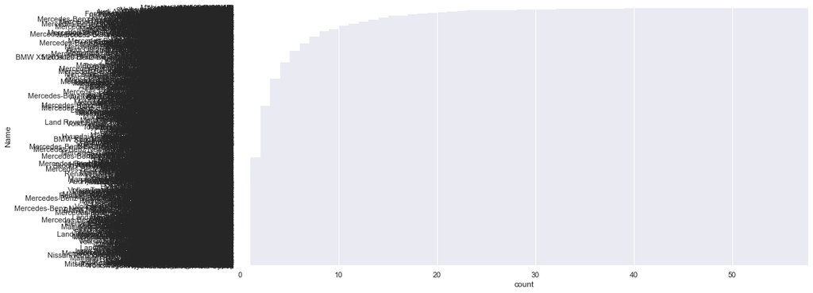

```python
#Let us plot a graph with feature Name
plt.figure(figsize=(15, 7))
sns.countplot(y="Name", data=data1, order=data1["Name"].value_counts().index)
```

There are so many unique values in Name column we can not analyze any trend out of it. Plot is very messy. Since in our dataset name consists of two parts, let's split it into Brand Name and Model Name.

```python
# Split Name column and get Brand Name and Model Name
data1["Brand_Name"] = data1["Name"].apply(lambda x: x.split(" ")[0].lower()) #first index of list is brand name

data1["Model_Name"] = data1["Name"].apply(lambda x: x.split(" ")[1].lower()) #second index of list is model name
```

```python
print(
    f'There are {data1["Brand_Name"].nunique()} unique brands and {data1["Model_Name"].nunique()} unique models'
)
```

```
There are 32 unique brands and 218 unique models
```

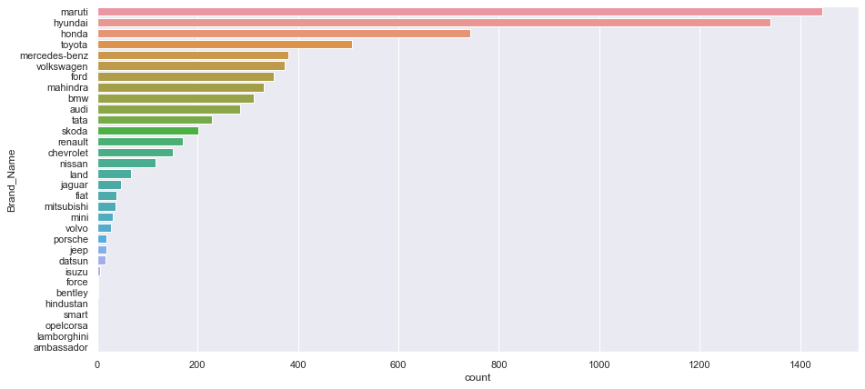

```python
#Plot the brand name vs their count

plt.figure(figsize=(15, 7))

sns.countplot(
    y="Brand_Name", data=data1, order=data1["Brand_Name"].value_counts().index
)
```

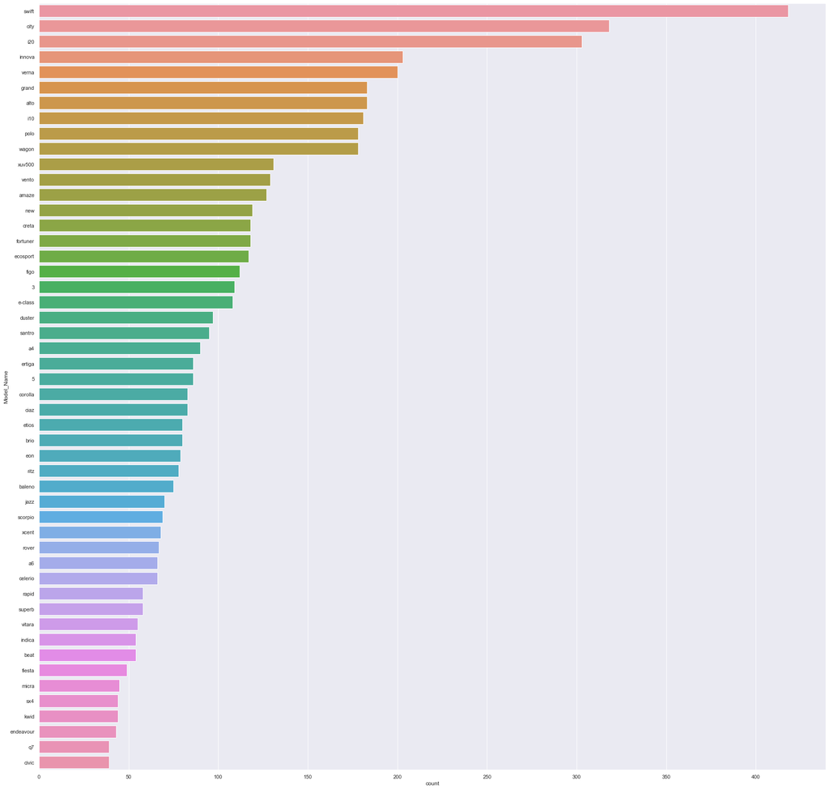

```python
# Since there 218 unique models, let's plot top 50

plt.figure(figsize=(30, 30))

sns.countplot(
    y="Model_Name", data=data1, order=data1["Model_Name"].value_counts().index[:50]
)
```

```python
# Grouping the Brand_Name with Price column
# it can be concluded that high end brands have higher price tag and price goes down as with brand recognition.

data1.groupby(["Brand_Name"])["Price"].mean().sort_values(ascending=False)
```

```
Brand_Name
lamborghini      120.000000
bentley           59.000000
porsche           48.348333
land              39.259500
jaguar            37.632250
mini              26.896923
mercedes-benz     26.809874
audi              25.537712
bmw               25.243146
volvo             18.802857
jeep              18.718667
isuzu             14.696667
toyota            11.580024
mitsubishi        11.058889
force              9.333333
mahindra           8.045919
skoda              7.559075
ford               6.889400
renault            5.799034
honda              5.411743
hyundai            5.343433
volkswagen         5.307270
nissan             4.738352
maruti             4.517267
tata               3.562849
fiat               3.269286
datsun             3.049231
chevrolet          3.044463
smart              3.000000
ambassador         1.350000
hindustan               NaN
opelcorsa               NaN
Name: Price, dtype: float64
```

## Performing EDA - Exploratory Data Analysis

```python
print("The number of empty cells or null or NaNs in each column \n")
print("\nColumn Name : \n", "-----------------", "\n", data1.isnull().sum())
```

```
The number of empty cells or null or NaNs in each column


Column Name :
 -----------------
 S.No.                       0
Name                        0
Location                    0
Year                        0
Kilometers_Driven           0
Fuel_Type                   0
Transmission                0
Owner_Type                  0
Mileage                     2
Engine                     46
Power                     175
Seats                      53
New_Price                6247
Price                    1234
engine_numerical_data      46
power_numerical_data      175
power_numerical_value     175
km_per_unit_fuel            2
measurement_unit            2
new_price_num            6247
Brand_Name                  0
Model_Name                  0
dtype: int64
```

```python
# Let's get the summary stats of the dataset
data1.describe().T
```

|  | count | mean | std | min | 25% | 50% | 75% | max |
| --- | --- | --- | --- | --- | --- | --- | --- | --- |
| S.No. | 7253.0 | 3626.000000 | 2093.905084 | 0.00 | 1813.000 | 3626.00 | 5439.0000 | 7252.00 |
| Year | 7253.0 | 2013.365366 | 3.254421 | 1996.00 | 2011.000 | 2014.00 | 2016.0000 | 2019.00 |
| Kilometers_Driven | 7253.0 | 58699.063146 | 84427.720583 | 171.00 | 34000.000 | 53416.00 | 73000.0000 | 6500000.00 |
| Seats | 7200.0 | 5.279722 | 0.811660 | 0.00 | 5.000 | 5.00 | 5.0000 | 10.00 |
| Price | 6019.0 | 9.479468 | 11.187917 | 0.44 | 3.500 | 5.64 | 9.9500 | 160.00 |
| engine_numerical_data | 7207.0 | 1616.573470 | 595.285137 | 72.00 | 1198.000 | 1493.00 | 1968.0000 | 5998.00 |
| power_numerical_data | 7078.0 | 112.765214 | 53.493553 | 34.20 | 75.000 | 94.00 | 138.1000 | 616.00 |
| power_numerical_value | 7078.0 | 112.765214 | 53.493553 | 34.20 | 75.000 | 94.00 | 138.1000 | 616.00 |
| km_per_unit_fuel | 7251.0 | 18.141580 | 4.562197 | 0.00 | 15.170 | 18.16 | 21.1000 | 33.54 |
| new_price_num | 1006.0 | 22.779692 | 27.759344 | 3.91 | 7.885 | 11.57 | 26.0425 | 375.00 |

```python
# checking extreme values in Kilometers_Driven
data1.sort_values(by=["Kilometers_Driven"], ascending=False).head(10)
```

|  | S.No. | Name | Location | Year | Kilometers_Driven | Fuel_Type | Transmission | Owner_Type | Mileage | Engine | Power | Seats | New_Price | Price | engine_numerical_data | power_numerical_data | power_numerical_value | km_per_unit_fuel | measurement_unit | new_price_num | Brand_Name | Model_Name |
| --- | --- | --- | --- | --- | --- | --- | --- | --- | --- | --- | --- | --- | --- | --- | --- | --- | --- | --- | --- | --- | --- | --- |
| 2328 | 2328 | BMW X5 xDrive 30d M Sport | Chennai | 2017 | 6500000 | Diesel | Automatic | First | 15.97 kmpl | 2993 CC | 258 bhp | 5.0 | NaN | 65.00 | 2993.0 | 258.00 | 258.00 | 15.97 | kmpl | NaN | bmw | x5 |
| 340 | 340 | Skoda Octavia Ambition Plus 2.0 TDI AT | Kolkata | 2013 | 775000 | Diesel | Automatic | First | 19.3 kmpl | 1968 CC | 141 bhp | 5.0 | NaN | 7.50 | 1968.0 | 141.00 | 141.00 | 19.30 | kmpl | NaN | skoda | octavia |
| 1860 | 1860 | Volkswagen Vento Diesel Highline | Chennai | 2013 | 720000 | Diesel | Manual | First | 20.54 kmpl | 1598 CC | 103.6 bhp | 5.0 | NaN | 5.90 | 1598.0 | 103.60 | 103.60 | 20.54 | kmpl | NaN | volkswagen | vento |
| 358 | 358 | Hyundai i10 Magna 1.2 | Chennai | 2009 | 620000 | Petrol | Manual | First | 20.36 kmpl | 1197 CC | 78.9 bhp | 5.0 | NaN | 2.70 | 1197.0 | 78.90 | 78.90 | 20.36 | kmpl | NaN | hyundai | i10 |
| 2823 | 2823 | Volkswagen Jetta 2013-2015 2.0L TDI Highline AT | Chennai | 2015 | 480000 | Diesel | Automatic | First | 16.96 kmpl | 1968 CC | 138.03 bhp | 5.0 | NaN | 13.00 | 1968.0 | 138.03 | 138.03 | 16.96 | kmpl | NaN | volkswagen | jetta |
| 3092 | 3092 | Honda City i VTEC SV | Kolkata | 2015 | 480000 | Petrol | Manual | First | 17.4 kmpl | 1497 CC | 117.3 bhp | 5.0 | NaN | 5.00 | 1497.0 | 117.30 | 117.30 | 17.40 | kmpl | NaN | honda | city |
| 4491 | 4491 | Hyundai i20 Magna Optional 1.2 | Bangalore | 2013 | 445000 | Petrol | Manual | First | 18.5 kmpl | 1197 CC | 82.9 bhp | 5.0 | NaN | 4.45 | 1197.0 | 82.90 | 82.90 | 18.50 | kmpl | NaN | hyundai | i20 |
| 6921 | 6921 | Maruti Swift Dzire Tour LDI | Jaipur | 2012 | 350000 | Diesel | Manual | First | 23.4 kmpl | 1248 CC | 74 bhp | 5.0 | NaN | NaN | 1248.0 | 74.00 | 74.00 | 23.40 | kmpl | NaN | maruti | swift |
| 3649 | 3649 | Tata Indigo LS | Jaipur | 2008 | 300000 | Diesel | Manual | First | 17.0 kmpl | 1405 CC | 70 bhp | 5.0 | NaN | 1.00 | 1405.0 | 70.00 | 70.00 | 17.00 | kmpl | NaN | tata | indigo |
| 1528 | 1528 | Toyota Innova 2.5 G (Diesel) 8 Seater BS IV | Hyderabad | 2005 | 299322 | Diesel | Manual | First | 12.8 kmpl | 2494 CC | 102 bhp | 8.0 | NaN | 4.00 | 2494.0 | 102.00 | 102.00 | 12.80 | kmpl | NaN | toyota | innova |

It looks like the first row here is a data entry error. A car manufactured as recently as 2017 having been driven 6500000 km is almost impossible.

We can check it using univariate analysis(box plot) whether it's outlier or not.

```python
# checking extreme values in Kilometers_Driven
data1.sort_values(by=["Kilometers_Driven"], ascending=True).head(10)
```

|  | S.No. | Name | Location | Year | Kilometers_Driven | Fuel_Type | Transmission | Owner_Type | Mileage | Engine | Power | Seats | New_Price | Price | engine_numerical_data | power_numerical_data | power_numerical_value | km_per_unit_fuel | measurement_unit | new_price_num | Brand_Name | Model_Name |
| --- | --- | --- | --- | --- | --- | --- | --- | --- | --- | --- | --- | --- | --- | --- | --- | --- | --- | --- | --- | --- | --- | --- |
| 1361 | 1361 | Maruti Alto 800 2016-2019 VXI | Mumbai | 2019 | 171 | Petrol | Manual | First | 24.7 kmpl | 796 CC | 47.3 bhp | 5.0 | NaN | 3.60 | 796.0 | 47.30 | 47.30 | 24.70 | kmpl | NaN | maruti | alto |
| 5606 | 5606 | Maruti Wagon R ZXI AMT 1.2 | Mumbai | 2019 | 600 | Petrol | Automatic | First | 21.5 kmpl | 1197 CC | 81.80 bhp | 5.0 | 6.8 Lakh | 6.25 | 1197.0 | 81.80 | 81.80 | 21.50 | kmpl | 6.80 | maruti | wagon |
| 1198 | 1198 | Volkswagen Polo 1.0 MPI Trendline | Hyderabad | 2019 | 1000 | Petrol | Manual | First | 18.78 kmpl | 999 CC | 75 bhp | 5.0 | 6.74 Lakh | 5.68 | 999.0 | 75.00 | 75.00 | 18.78 | kmpl | 6.74 | volkswagen | polo |
| 5941 | 5941 | Renault KWID RXL | Pune | 2018 | 1000 | Petrol | Manual | First | 25.17 kmpl | 799 CC | 53.3 bhp | 5.0 | 4.45 Lakh | 3.40 | 799.0 | 53.30 | 53.30 | 25.17 | kmpl | 4.45 | renault | kwid |
| 6201 | 6201 | Maruti Alto LXI | Kolkata | 2019 | 1000 | Petrol | Manual | First | 24.7 kmpl | 796 CC | 47.3 bhp | 5.0 | 3.99 Lakh | NaN | 796.0 | 47.30 | 47.30 | 24.70 | kmpl | 3.99 | maruti | alto |
| 1161 | 1161 | Tata Tigor 1.2 Revotron XTA | Ahmedabad | 2018 | 1000 | Petrol | Automatic | First | 20.3 kmpl | 1199 CC | 84 bhp | 5.0 | NaN | 6.85 | 1199.0 | 84.00 | 84.00 | 20.30 | kmpl | NaN | tata | tigor |
| 1598 | 1598 | Tata Xenon XT EX 4X2 | Jaipur | 2017 | 1000 | Diesel | Manual | First | 13.49 kmpl | 2179 CC | 138.03 bhp | 5.0 | NaN | 7.50 | 2179.0 | 138.03 | 138.03 | 13.49 | kmpl | NaN | tata | xenon |
| 173 | 173 | Hyundai Grand i10 1.2 Kappa Asta | Kolkata | 2019 | 1000 | Petrol | Manual | First | 18.9 kmpl | 1197 CC | 81.86 bhp | 5.0 | 7.39 Lakh | 6.50 | 1197.0 | 81.86 | 81.86 | 18.90 | kmpl | 7.39 | hyundai | grand |
| 1242 | 1242 | Jaguar XE 2.0L Diesel Prestige | Delhi | 2018 | 1000 | Diesel | Automatic | First | 13.6 kmpl | 1999 CC | 177 bhp | 5.0 | 52.77 Lakh | 40.00 | 1999.0 | 177.00 | 177.00 | 13.60 | kmpl | 52.77 | jaguar | xe |
| 5339 | 5339 | Hyundai i20 Active SX Dual Tone Petrol | Pune | 2019 | 1000 | Petrol | Manual | First | 17.19 kmpl | 1197 CC | 81.86 bhp | 5.0 | 10.25 Lakh | 8.60 | 1197.0 | 81.86 | 81.86 | 17.19 | kmpl | 10.25 | hyundai | i20 |

```python
data1.sort_values(by=["Seats"], ascending=True).head(10)
```

|  | S.No. | Name | Location | Year | Kilometers_Driven | Fuel_Type | Transmission | Owner_Type | Mileage | Engine | Power | Seats | New_Price | Price | engine_numerical_data | power_numerical_data | power_numerical_value | km_per_unit_fuel | measurement_unit | new_price_num | Brand_Name | Model_Name |
| --- | --- | --- | --- | --- | --- | --- | --- | --- | --- | --- | --- | --- | --- | --- | --- | --- | --- | --- | --- | --- | --- | --- |
| 3999 | 3999 | Audi A4 3.2 FSI Tiptronic Quattro | Hyderabad | 2012 | 125000 | Petrol | Automatic | First | 10.5 kmpl | 3197 CC | NaN | 0.0 | NaN | 18.00 | 3197.0 | NaN | NaN | 10.5 | kmpl | NaN | audi | a4 |
| 693 | 693 | Mercedes-Benz SLK-Class SLK 350 | Coimbatore | 2016 | 22732 | Petrol | Automatic | First | 18.1 kmpl | 3498 CC | 306 bhp | 2.0 | NaN | 55.54 | 3498.0 | 306.00 | 306.00 | 18.1 | kmpl | NaN | mercedes-benz | slk-class |
| 798 | 798 | Mercedes-Benz SLK-Class SLK 350 | Bangalore | 2015 | 10000 | Petrol | Automatic | First | 18.1 kmpl | 3498 CC | 306 bhp | 2.0 | NaN | 55.00 | 3498.0 | 306.00 | 306.00 | 18.1 | kmpl | NaN | mercedes-benz | slk-class |
| 5781 | 5781 | Lamborghini Gallardo Coupe | Delhi | 2011 | 6500 | Petrol | Automatic | Third | 6.4 kmpl | 5204 CC | 560 bhp | 2.0 | NaN | 120.00 | 5204.0 | 560.00 | 560.00 | 6.4 | kmpl | NaN | lamborghini | gallardo |
| 4722 | 4722 | Mercedes-Benz SL-Class SL 500 | Kolkata | 2010 | 35000 | Petrol | Automatic | First | 8.1 kmpl | 5461 CC | 387.3 bhp | 2.0 | NaN | 29.50 | 5461.0 | 387.30 | 387.30 | 8.1 | kmpl | NaN | mercedes-benz | sl-class |
| 134 | 134 | Mercedes-Benz SLC 43 AMG | Kolkata | 2017 | 13372 | Petrol | Automatic | First | 19.0 kmpl | 2996 CC | 362.07 bhp | 2.0 | 95.04 Lakh | 54.00 | 2996.0 | 362.07 | 362.07 | 19.0 | kmpl | 95.04 | mercedes-benz | slc |
| 915 | 915 | Smart Fortwo CDI AT | Pune | 2008 | 103000 | Diesel | Automatic | Second | 0.0 kmpl | 799 CC | NaN | 2.0 | NaN | 3.00 | 799.0 | NaN | NaN | 0.0 | kmpl | NaN | smart | fortwo |
| 926 | 926 | Porsche Cayman 2009-2012 S | Hyderabad | 2010 | 10000 | Petrol | Manual | First | 9.0 kmpl | 3436 CC | NaN | 2.0 | NaN | 40.00 | 3436.0 | NaN | NaN | 9.0 | kmpl | NaN | porsche | cayman |
| 5919 | 5919 | Jaguar F Type 5.0 V8 S | Hyderabad | 2015 | 8000 | Petrol | Automatic | First | 12.5 kmpl | 5000 CC | 488.1 bhp | 2.0 | NaN | 100.00 | 5000.0 | 488.10 | 488.10 | 12.5 | kmpl | NaN | jaguar | f |
| 4691 | 4691 | Mercedes-Benz SLK-Class 55 AMG | Bangalore | 2014 | 3000 | Petrol | Automatic | Second | 12.0 kmpl | 5461 CC | 421 bhp | 2.0 | NaN | 90.00 | 5461.0 | 421.00 | 421.00 | 12.0 | kmpl | NaN | mercedes-benz | slk-class |

It shows that Audi A4 has 0 seats. It may due to some outlier (data entry error).

```python
# Let us check if we have a similar car in our dataset.
data1[data1["Name"].str.startswith("Audi A4")]
```

|  | S.No. | Name | Location | Year | Kilometers_Driven | Fuel_Type | Transmission | Owner_Type | Mileage | Engine | Power | Seats | New_Price | Price | engine_numerical_data | power_numerical_data | power_numerical_value | km_per_unit_fuel | measurement_unit | new_price_num | Brand_Name | Model_Name |
| --- | --- | --- | --- | --- | --- | --- | --- | --- | --- | --- | --- | --- | --- | --- | --- | --- | --- | --- | --- | --- | --- | --- |
| 4 | 4 | Audi A4 New 2.0 TDI Multitronic | Coimbatore | 2013 | 40670 | Diesel | Automatic | Second | 15.2 kmpl | 1968 CC | 140.8 bhp | 5.0 | NaN | 17.74 | 1968.0 | 140.80 | 140.80 | 15.20 | kmpl | NaN | audi | a4 |
| 50 | 50 | Audi A4 2.0 TDI 177 Bhp Premium Plus | Kochi | 2015 | 13648 | Diesel | Automatic | First | 17.11 kmpl | 1968 CC | 174.33 bhp | 5.0 | NaN | 21.43 | 1968.0 | 174.33 | 174.33 | 17.11 | kmpl | NaN | audi | a4 |
| 65 | 65 | Audi A4 2.0 TDI Multitronic | Jaipur | 2012 | 65664 | Diesel | Automatic | First | 16.55 kmpl | 1968 CC | 140 bhp | 5.0 | NaN | 13.50 | 1968.0 | 140.00 | 140.00 | 16.55 | kmpl | NaN | audi | a4 |
| 103 | 103 | Audi A4 3.0 TDI Quattro Premium | Kolkata | 2010 | 30000 | Diesel | Automatic | First | 14.94 kmpl | 2967 CC | 241.4 bhp | 5.0 | NaN | 9.80 | 2967.0 | 241.40 | 241.40 | 14.94 | kmpl | NaN | audi | a4 |
| 150 | 150 | Audi A4 2.0 TDI 177 Bhp Premium Plus | Coimbatore | 2015 | 48214 | Diesel | Automatic | First | 17.11 kmpl | 1968 CC | 174.33 bhp | 5.0 | NaN | 23.32 | 1968.0 | 174.33 | 174.33 | 17.11 | kmpl | NaN | audi | a4 |
| 717 | 717 | Audi A4 2.0 TDI 177 Bhp Premium Plus | Bangalore | 2013 | 45979 | Diesel | Automatic | Second | 17.11 kmpl | 1968 CC | 174.33 bhp | 5.0 | NaN | 19.50 | 1968.0 | 174.33 | 174.33 | 17.11 | kmpl | NaN | audi | a4 |
| 853 | 853 | Audi A4 2.0 TDI | Delhi | 2011 | 46000 | Diesel | Automatic | Second | 16.55 kmpl | 1968 CC | 147.51 bhp | 5.0 | NaN | 10.99 | 1968.0 | 147.51 | 147.51 | 16.55 | kmpl | NaN | audi | a4 |
| 854 | 854 | Audi A4 2.0 TDI | Kolkata | 2012 | 47346 | Diesel | Automatic | First | 16.55 kmpl | 1968 CC | 147.51 bhp | 5.0 | NaN | 14.50 | 1968.0 | 147.51 | 147.51 | 16.55 | kmpl | NaN | audi | a4 |
| 874 | 874 | Audi A4 2.0 TDI Multitronic | Ahmedabad | 2011 | 59000 | Diesel | Automatic | First | 16.55 kmpl | 1968 CC | 140 bhp | 5.0 | NaN | 12.50 | 1968.0 | 140.00 | 140.00 | 16.55 | kmpl | NaN | audi | a4 |
| 964 | 964 | Audi A4 2.0 TDI | Kolkata | 2009 | 34000 | Diesel | Automatic | First | 16.55 kmpl | 1968 CC | 147.51 bhp | 5.0 | NaN | 9.95 | 1968.0 | 147.51 | 147.51 | 16.55 | kmpl | NaN | audi | a4 |
| 1044 | 1044 | Audi A4 35 TDI Technology | Hyderabad | 2015 | 45000 | Diesel | Automatic | First | 18.25 kmpl | 1968 CC | 187.74 bhp | 5.0 | 55.61 Lakh | 25.00 | 1968.0 | 187.74 | 187.74 | 18.25 | kmpl | 55.61 | audi | a4 |
| 1268 | 1268 | Audi A4 2.0 TDI 177 Bhp Premium Plus | Kochi | 2014 | 77395 | Diesel | Automatic | First | 17.11 kmpl | 1968 CC | 174.33 bhp | 5.0 | NaN | 14.35 | 1968.0 | 174.33 | 174.33 | 17.11 | kmpl | NaN | audi | a4 |
| 1316 | 1316 | Audi A4 2.0 TDI | Delhi | 2013 | 36000 | Diesel | Automatic | Second | 16.55 kmpl | 1968 CC | 147.51 bhp | 5.0 | NaN | 14.00 | 1968.0 | 147.51 | 147.51 | 16.55 | kmpl | NaN | audi | a4 |
| 1637 | 1637 | Audi A4 35 TDI Premium | Coimbatore | 2016 | 68193 | Diesel | Automatic | First | 17.11 kmpl | 1968 CC | 174.33 bhp | 5.0 | NaN | 24.74 | 1968.0 | 174.33 | 174.33 | 17.11 | kmpl | NaN | audi | a4 |
| 1807 | 1807 | Audi A4 2.0 TDI 177 Bhp Premium Plus | Bangalore | 2014 | 21000 | Diesel | Automatic | First | 17.11 kmpl | 1968 CC | 174.33 bhp | 5.0 | NaN | 24.50 | 1968.0 | 174.33 | 174.33 | 17.11 | kmpl | NaN | audi | a4 |
| 1868 | 1868 | Audi A4 New 2.0 TDI Multitronic | Delhi | 2012 | 60000 | Diesel | Automatic | Second | 15.2 kmpl | 1968 CC | 140.8 bhp | 5.0 | NaN | 10.35 | 1968.0 | 140.80 | 140.80 | 15.20 | kmpl | NaN | audi | a4 |
| 1900 | 1900 | Audi A4 3.0 TDI Quattro Premium | Coimbatore | 2012 | 46913 | Diesel | Automatic | First | 14.94 kmpl | 2967 CC | 241.4 bhp | 5.0 | NaN | 16.11 | 2967.0 | 241.40 | 241.40 | 14.94 | kmpl | NaN | audi | a4 |
| 1918 | 1918 | Audi A4 2.0 TDI | Kochi | 2013 | 45330 | Diesel | Automatic | First | 16.55 kmpl | 1968 CC | 147.51 bhp | 5.0 | NaN | 13.19 | 1968.0 | 147.51 | 147.51 | 16.55 | kmpl | NaN | audi | a4 |
| 1929 | 1929 | Audi A4 2.0 TDI 177 Bhp Premium Plus | Chennai | 2014 | 70000 | Diesel | Automatic | First | 17.11 kmpl | 1968 CC | 174.33 bhp | 5.0 | NaN | 18.00 | 1968.0 | 174.33 | 174.33 | 17.11 | kmpl | NaN | audi | a4 |
| 2005 | 2005 | Audi A4 2.0 TDI | Ahmedabad | 2013 | 82002 | Diesel | Automatic | Second | 16.55 kmpl | 1968 CC | 147.51 bhp | 5.0 | NaN | 17.50 | 1968.0 | 147.51 | 147.51 | 16.55 | kmpl | NaN | audi | a4 |
| 2024 | 2024 | Audi A4 New 2.0 TDI Multitronic | Delhi | 2012 | 44555 | Diesel | Automatic | First | 15.2 kmpl | 1968 CC | 140.8 bhp | 5.0 | NaN | 13.50 | 1968.0 | 140.80 | 140.80 | 15.20 | kmpl | NaN | audi | a4 |
| 2044 | 2044 | Audi A4 2.0 TDI | Delhi | 2013 | 67000 | Diesel | Automatic | First | 16.55 kmpl | 1968 CC | 147.51 bhp | 5.0 | NaN | 14.50 | 1968.0 | 147.51 | 147.51 | 16.55 | kmpl | NaN | audi | a4 |
| 2060 | 2060 | Audi A4 2.0 TDI 177 Bhp Technology Edition | Bangalore | 2014 | 24000 | Diesel | Automatic | First | 17.11 kmpl | 1968 CC | 174.33 bhp | 5.0 | NaN | 25.00 | 1968.0 | 174.33 | 174.33 | 17.11 | kmpl | NaN | audi | a4 |
| 2078 | 2078 | Audi A4 2.0 TDI Multitronic | Jaipur | 2011 | 105000 | Diesel | Automatic | Second | 16.55 kmpl | 1968 CC | 140 bhp | 5.0 | NaN | 14.50 | 1968.0 | 140.00 | 140.00 | 16.55 | kmpl | NaN | audi | a4 |
| 2084 | 2084 | Audi A4 2.0 TDI | Mumbai | 2013 | 45200 | Diesel | Automatic | First | 16.55 kmpl | 1968 CC | 147.51 bhp | 5.0 | NaN | 13.50 | 1968.0 | 147.51 | 147.51 | 16.55 | kmpl | NaN | audi | a4 |
| 2114 | 2114 | Audi A4 35 TDI Premium | Hyderabad | 2015 | 50000 | Diesel | Automatic | First | 17.11 kmpl | 1968 CC | 174.33 bhp | 5.0 | NaN | 25.00 | 1968.0 | 174.33 | 174.33 | 17.11 | kmpl | NaN | audi | a4 |
| 2189 | 2189 | Audi A4 2.0 TFSI | Mumbai | 2011 | 38000 | Petrol | Automatic | First | 10.8 kmpl | 1984 CC | 132 bhp | 5.0 | NaN | 12.00 | 1984.0 | 132.00 | 132.00 | 10.80 | kmpl | NaN | audi | a4 |
| 2240 | 2240 | Audi A4 2.0 TDI | Hyderabad | 2014 | 60000 | Diesel | Automatic | First | 16.55 kmpl | 1968 CC | 147.51 bhp | 5.0 | NaN | 24.00 | 1968.0 | 147.51 | 147.51 | 16.55 | kmpl | NaN | audi | a4 |
| 2284 | 2284 | Audi A4 2.0 TDI 177 Bhp Premium Plus | Pune | 2013 | 87000 | Diesel | Automatic | First | 17.11 kmpl | 1968 CC | 174.33 bhp | 5.0 | NaN | 15.50 | 1968.0 | 174.33 | 174.33 | 17.11 | kmpl | NaN | audi | a4 |
| 2298 | 2298 | Audi A4 2.0 TDI | Hyderabad | 2011 | 85000 | Diesel | Automatic | First | 16.55 kmpl | 1968 CC | 147.51 bhp | 5.0 | NaN | 13.95 | 1968.0 | 147.51 | 147.51 | 16.55 | kmpl | NaN | audi | a4 |

[output cut: 60 more lines]

It indicates the Audi A4 typically has 5 seats.

```python
# Let us replace #seats in row index 3999 (Audi A4 carrying 0 seat) with 5 (general seat in Audi car)
data1.loc[3999, "Seats"] = 5.0
```

It indicates the Audi A4 typically has 5 seats.

```python
# Check maximum no seat in cars
data1.sort_values(by=["Seats"], ascending=False).head(10)
```

|  | S.No. | Name | Location | Year | Kilometers_Driven | Fuel_Type | Transmission | Owner_Type | Mileage | Engine | Power | Seats | New_Price | Price | engine_numerical_data | power_numerical_data | power_numerical_value | km_per_unit_fuel | measurement_unit | new_price_num | Brand_Name | Model_Name |
| --- | --- | --- | --- | --- | --- | --- | --- | --- | --- | --- | --- | --- | --- | --- | --- | --- | --- | --- | --- | --- | --- | --- |
| 2575 | 2575 | Chevrolet Tavera LS B3 10 Seats BSIII | Hyderabad | 2015 | 120000 | Diesel | Manual | First | 14.8 kmpl | 2499 CC | 80 bhp | 10.0 | NaN | 5.50 | 2499.0 | 80.0 | 80.0 | 14.80 | kmpl | NaN | chevrolet | tavera |
| 1907 | 1907 | Toyota Qualis FS B3 | Bangalore | 2002 | 63000 | Diesel | Manual | Third | 13.1 kmpl | 2446 CC | 75 bhp | 10.0 | NaN | 3.65 | 2446.0 | 75.0 | 75.0 | 13.10 | kmpl | NaN | toyota | qualis |
| 6288 | 6288 | Chevrolet Tavera LS B3 10 Seats BSIII | Hyderabad | 2005 | 150000 | Diesel | Manual | Second | 14.8 kmpl | 2499 CC | 80 bhp | 10.0 | NaN | NaN | 2499.0 | 80.0 | 80.0 | 14.80 | kmpl | NaN | chevrolet | tavera |
| 6242 | 6242 | Tata Sumo EX 10/7 Str BSII | Chennai | 2015 | 196000 | Diesel | Manual | Second | 12.2 kmpl | 1948 CC | 68 bhp | 10.0 | NaN | NaN | 1948.0 | 68.0 | 68.0 | 12.20 | kmpl | NaN | tata | sumo |
| 814 | 814 | Toyota Qualis FS B2 | Pune | 2004 | 77757 | Diesel | Manual | Second | 13.1 kmpl | 2446 CC | 75 bhp | 10.0 | NaN | 3.50 | 2446.0 | 75.0 | 75.0 | 13.10 | kmpl | NaN | toyota | qualis |
| 917 | 917 | Tata Sumo DX | Mumbai | 2013 | 20000 | Diesel | Manual | First | 14.07 kmpl | 1978 CC | 83.1 bhp | 10.0 | NaN | 5.25 | 1978.0 | 83.1 | 83.1 | 14.07 | kmpl | NaN | tata | sumo |
| 6875 | 6875 | Toyota Qualis FS B3 | Pune | 2002 | 119613 | Diesel | Manual | Second | 13.1 kmpl | 2446 CC | 75 bhp | 10.0 | NaN | NaN | 2446.0 | 75.0 | 75.0 | 13.10 | kmpl | NaN | toyota | qualis |
| 2267 | 2267 | Toyota Qualis RS E2 | Pune | 2004 | 215750 | Diesel | Manual | Second | 0.0 kmpl | 2446 CC | NaN | 10.0 | NaN | 3.50 | 2446.0 | NaN | NaN | 0.00 | kmpl | NaN | toyota | qualis |
| 2312 | 2312 | Chevrolet Tavera LT 9 Str BS IV | Kolkata | 2012 | 67132 | Diesel | Manual | First | 13.58 kmpl | 2499 CC | 78 bhp | 9.0 | NaN | 4.75 | 2499.0 | 78.0 | 78.0 | 13.58 | kmpl | NaN | chevrolet | tavera |
| 2359 | 2359 | Mahindra Xylo D2 Maxx | Chennai | 2016 | 150000 | Diesel | Manual | First | 14.95 kmpl | 2489 CC | 93.7 bhp | 9.0 | NaN | 4.50 | 2489.0 | 93.7 | 93.7 | 14.95 | kmpl | NaN | mahindra | xylo |

There are many cars with 10 no. of seats. It may not be an outlier in `seat` column of data.

```python
# checking extreme values in Mileage - km_per_unit_fuel
data1.sort_values(by=["km_per_unit_fuel"], ascending=True).head(10)
```

|  | S.No. | Name | Location | Year | Kilometers_Driven | Fuel_Type | Transmission | Owner_Type | Mileage | Engine | Power | Seats | New_Price | Price | engine_numerical_data | power_numerical_data | power_numerical_value | km_per_unit_fuel | measurement_unit | new_price_num | Brand_Name | Model_Name |
| --- | --- | --- | --- | --- | --- | --- | --- | --- | --- | --- | --- | --- | --- | --- | --- | --- | --- | --- | --- | --- | --- | --- |
| 2597 | 2597 | Hyundai Santro Xing XP | Pune | 2007 | 70000 | Petrol | Manual | First | 0.0 kmpl | 1086 CC | NaN | 5.0 | NaN | 1.12 | 1086.0 | NaN | NaN | 0.0 | kmpl | NaN | hyundai | santro |
| 2343 | 2343 | Hyundai Santro AT | Hyderabad | 2006 | 74483 | Petrol | Automatic | First | 0.0 kmpl | 999 CC | NaN | 5.0 | NaN | 2.30 | 999.0 | NaN | NaN | 0.0 | kmpl | NaN | hyundai | santro |
| 5270 | 5270 | Honda City 1.5 GXI | Bangalore | 2002 | 53000 | Petrol | Manual | Second | 0.0 kmpl | NaN | NaN | NaN | NaN | 1.85 | NaN | NaN | NaN | 0.0 | kmpl | NaN | honda | city |
| 424 | 424 | Volkswagen Jetta 2007-2011 1.9 L TDI | Hyderabad | 2010 | 42021 | Diesel | Manual | First | 0.0 kmpl | 1968 CC | NaN | 5.0 | NaN | 5.45 | 1968.0 | NaN | NaN | 0.0 | kmpl | NaN | volkswagen | jetta |
| 6857 | 6857 | Land Rover Freelander 2 TD4 SE | Mumbai | 2011 | 87000 | Diesel | Automatic | First | 0.0 kmpl | 2179 CC | 115 bhp | 5.0 | NaN | NaN | 2179.0 | 115.0 | 115.0 | 0.0 | kmpl | NaN | land | rover |
| 443 | 443 | Hyundai Santro GLS I - Euro I | Coimbatore | 2012 | 50243 | Petrol | Manual | First | 0.0 kmpl | 1086 CC | NaN | 5.0 | NaN | 3.35 | 1086.0 | NaN | NaN | 0.0 | kmpl | NaN | hyundai | santro |
| 5119 | 5119 | Hyundai Santro Xing XP | Kolkata | 2008 | 45500 | Petrol | Manual | Second | 0.0 kmpl | 1086 CC | NaN | 5.0 | NaN | 1.17 | 1086.0 | NaN | NaN | 0.0 | kmpl | NaN | hyundai | santro |
| 5022 | 5022 | Land Rover Freelander 2 TD4 SE | Hyderabad | 2013 | 46000 | Diesel | Automatic | Second | 0.0 kmpl | 2179 CC | 115 bhp | 5.0 | NaN | 26.00 | 2179.0 | 115.0 | 115.0 | 0.0 | kmpl | NaN | land | rover |
| 5016 | 5016 | Land Rover Freelander 2 TD4 HSE | Delhi | 2013 | 72000 | Diesel | Automatic | First | 0.0 kmpl | 2179 CC | 115 bhp | 5.0 | NaN | 15.50 | 2179.0 | 115.0 | 115.0 | 0.0 | kmpl | NaN | land | rover |
| 2542 | 2542 | Hyundai Santro GLS II - Euro II | Bangalore | 2011 | 65000 | Petrol | Manual | Second | 0.0 kmpl | NaN | NaN | NaN | NaN | 3.15 | NaN | NaN | NaN | 0.0 | kmpl | NaN | hyundai | santro |

We will have to treat Mileage = 0 as missing values

## Missing Values

Before we start looking at the individual distributions and interactions, let's quickly check the missing entries in each column of the data

```python
data1.isnull().sum()
```

```
S.No.                       0
Name                        0
Location                    0
Year                        0
Kilometers_Driven           0
Fuel_Type                   0
Transmission                0
Owner_Type                  0
Mileage                     2
Engine                     46
Power                     175
Seats                      53
New_Price                6247
Price                    1234
engine_numerical_data      46
power_numerical_data      175
power_numerical_value     175
km_per_unit_fuel            2
measurement_unit            2
new_price_num            6247
Brand_Name                  0
Model_Name                  0
dtype: int64
```

1. 2 cars don't have entries for `Mileage`
2. `Engine`, `Power` of 46, 175 respectively data is missing
3. 175 entries missing in `power_numerical_value` column
4. 53 entries missing in `Seats` column
5. 6247 missing entries in `New_Price` column

```python
# dropping the redundant columns.
data1.drop(
    columns=["Mileage","Engine", "measurement_unit","Power", "power_numerical_data" ,"New_Price"], inplace=True
)
```

## Distributions

### Price

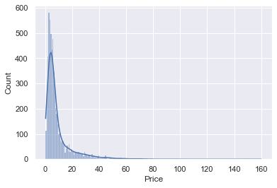

```python
sns.histplot(data=data1, x="Price", kde=True)
```

This is a highly skewed distribution. Let us use log transformation on this column to see if that helps normalize the distribution.

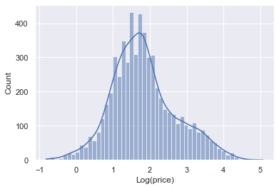

```python
sns.histplot(np.log(data1["Price"]), kde=True)
plt.xlabel("Log(price)")
```

Using the log transformation has definitely helped in reducing the skew.

```python
# Creating a new column with the transformed variable.
data1["price_log"] = np.log(data1["Price"])
```

### Price vs Location

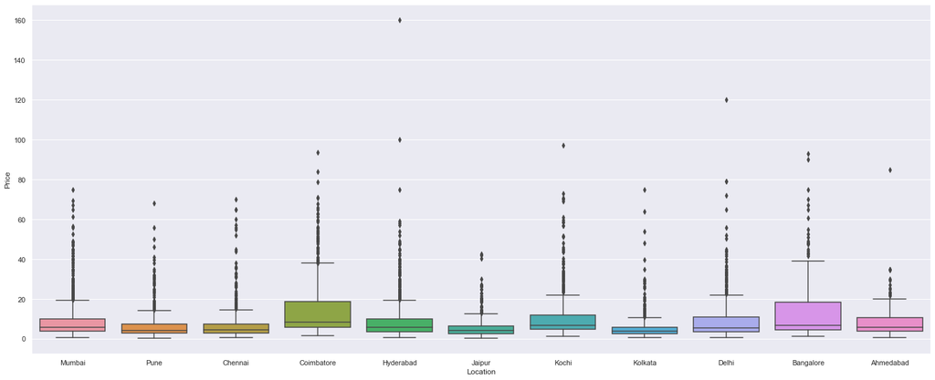

```python
plt.figure(figsize=(25, 10))
sns.boxplot(x="Location", y="Price", data=data1)
```

The price of used cars has a large IQR in Coimbatore and Bangalore

### Kilometers_Driven

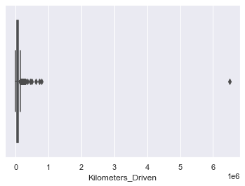

```python
sns.boxplot(data=data1, x="Kilometers_Driven")
```

It does have an outlier around 6500000 km, which we were guessing from EDA analysis

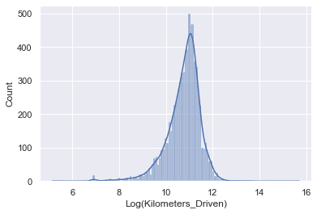

```python
# Log transformation
sns.histplot(np.log(data1["Kilometers_Driven"]), kde=True)
plt.xlabel("Log(Kilometers_Driven)")
```

Transformation has reduced the extreme skewness.

```python
data1["kilometers_driven_log"] = np.log(data1["Kilometers_Driven"])
```

### Bivariate Distributions

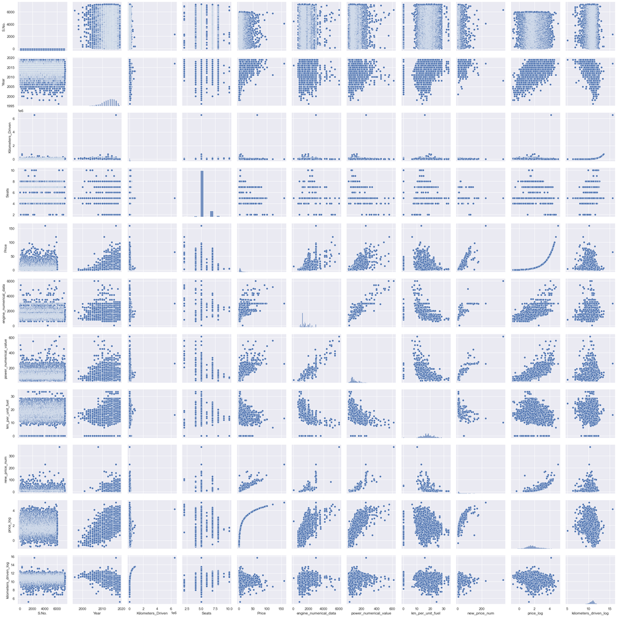

```python
sns.pairplot(data1)
```

Interpreation from plots

- Kilometers Driven does not seem to have a relationship with the price.
- New Price and Used Car Price are also positively correlated, which is expected.
- Kilometers Driven has some relationship with the Year variable.
- Mileage has a negative correlation with engine displacement and power. If engine has more power, it will consume more fuel.

### Correlation between numerical variables

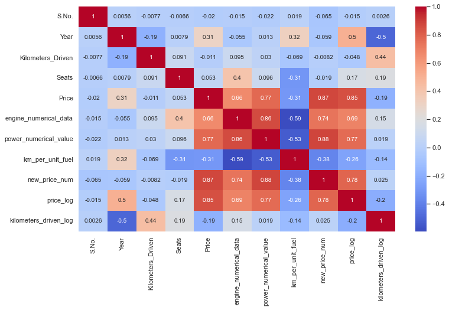

```python
plt.figure(figsize=(12, 7))
sns.heatmap(data1.corr(), annot=True, cmap="coolwarm")
```

## Missing Value Treatment

```python
# let's check again for missing values
data1.isnull().sum()
```

```
S.No.                       0
Name                        0
Location                    0
Year                        0
Kilometers_Driven           0
Fuel_Type                   0
Transmission                0
Owner_Type                  0
Seats                      53
Price                    1234
engine_numerical_data      46
power_numerical_value     175
km_per_unit_fuel            2
new_price_num            6247
Brand_Name                  0
Model_Name                  0
price_log                1234
kilometers_driven_log       0
dtype: int64
```

1. We have 53 missing elements in `seat` column
2. We have 46 elements missing in `engine_numerical_data` column
3. We have 175 elements missing in `power_numerical_value` column

### Seats

```python
# let's look at a few rows where seats is missing
data1[data1["Seats"].isnull()]
```

|  | S.No. | Name | Location | Year | Kilometers_Driven | Fuel_Type | Transmission | Owner_Type | Seats | Price | engine_numerical_data | power_numerical_value | km_per_unit_fuel | new_price_num | Brand_Name | Model_Name | price_log | kilometers_driven_log |
| --- | --- | --- | --- | --- | --- | --- | --- | --- | --- | --- | --- | --- | --- | --- | --- | --- | --- | --- |
| 194 | 194 | Honda City 1.5 GXI | Ahmedabad | 2007 | 60006 | Petrol | Manual | First | NaN | 2.95 | NaN | NaN | 0.00 | NaN | honda | city | 1.081805 | 11.002200 |
| 208 | 208 | Maruti Swift 1.3 VXi | Kolkata | 2010 | 42001 | Petrol | Manual | First | NaN | 2.11 | NaN | NaN | 16.10 | NaN | maruti | swift | 0.746688 | 10.645449 |
| 229 | 229 | Ford Figo Diesel | Bangalore | 2015 | 70436 | Diesel | Manual | First | NaN | 3.60 | 1498.0 | 99.0 | 0.00 | NaN | ford | figo | 1.280934 | 11.162460 |
| 733 | 733 | Maruti Swift 1.3 VXi | Chennai | 2006 | 97800 | Petrol | Manual | Third | NaN | 1.75 | NaN | NaN | 16.10 | NaN | maruti | swift | 0.559616 | 11.490680 |
| 749 | 749 | Land Rover Range Rover 3.0 D | Mumbai | 2008 | 55001 | Diesel | Automatic | Second | NaN | 26.50 | NaN | NaN | 0.00 | NaN | land | rover | 3.277145 | 10.915107 |
| 1294 | 1294 | Honda City 1.3 DX | Delhi | 2009 | 55005 | Petrol | Manual | First | NaN | 3.20 | NaN | NaN | 12.80 | NaN | honda | city | 1.163151 | 10.915179 |
| 1327 | 1327 | Maruti Swift 1.3 ZXI | Hyderabad | 2015 | 50295 | Petrol | Manual | First | NaN | 5.80 | NaN | NaN | 16.10 | NaN | maruti | swift | 1.757858 | 10.825661 |
| 1385 | 1385 | Honda City 1.5 GXI | Pune | 2004 | 115000 | Petrol | Manual | Second | NaN | 1.50 | NaN | NaN | 0.00 | NaN | honda | city | 0.405465 | 11.652687 |
| 1460 | 1460 | Land Rover Range Rover Sport 2005 2012 Sport | Coimbatore | 2008 | 69078 | Petrol | Manual | First | NaN | 40.88 | NaN | NaN | 0.00 | NaN | land | rover | 3.710641 | 11.142992 |
| 1917 | 1917 | Honda City 1.5 EXI | Jaipur | 2005 | 88000 | Petrol | Manual | Second | NaN | 1.70 | 1493.0 | 100.0 | 13.00 | NaN | honda | city | 0.530628 | 11.385092 |
| 2074 | 2074 | Maruti Swift 1.3 LXI | Pune | 2011 | 24255 | Petrol | Manual | First | NaN | 3.15 | NaN | NaN | 16.10 | NaN | maruti | swift | 1.147402 | 10.096378 |
| 2096 | 2096 | Hyundai Santro LP zipPlus | Coimbatore | 2004 | 52146 | Petrol | Manual | First | NaN | 1.93 | NaN | NaN | 0.00 | NaN | hyundai | santro | 0.657520 | 10.861803 |
| 2264 | 2264 | Toyota Etios Liva V | Pune | 2012 | 24500 | Petrol | Manual | Second | NaN | 2.95 | NaN | NaN | 18.30 | NaN | toyota | etios | 1.081805 | 10.106428 |
| 2325 | 2325 | Maruti Swift 1.3 VXI ABS | Pune | 2015 | 67000 | Petrol | Manual | First | NaN | 4.70 | NaN | NaN | 16.10 | NaN | maruti | swift | 1.547563 | 11.112448 |
| 2335 | 2335 | Maruti Swift 1.3 VXi | Mumbai | 2007 | 55000 | Petrol | Manual | Second | NaN | 1.75 | NaN | NaN | 16.10 | NaN | maruti | swift | 0.559616 | 10.915088 |
| 2369 | 2369 | Maruti Estilo LXI | Chennai | 2008 | 56000 | Petrol | Manual | Second | NaN | 1.50 | 1061.0 | NaN | 19.50 | NaN | maruti | estilo | 0.405465 | 10.933107 |
| 2530 | 2530 | BMW 5 Series 520d Sedan | Kochi | 2014 | 64158 | Diesel | Automatic | First | NaN | 17.89 | NaN | NaN | 18.48 | NaN | bmw | 5 | 2.884242 | 11.069104 |
| 2542 | 2542 | Hyundai Santro GLS II - Euro II | Bangalore | 2011 | 65000 | Petrol | Manual | Second | NaN | 3.15 | NaN | NaN | 0.00 | NaN | hyundai | santro | 1.147402 | 11.082143 |
| 2623 | 2623 | BMW 5 Series 520d Sedan | Pune | 2012 | 95000 | Diesel | Automatic | Second | NaN | 18.00 | NaN | NaN | 18.48 | NaN | bmw | 5 | 2.890372 | 11.461632 |
| 2668 | 2668 | Maruti Swift 1.3 VXi | Kolkata | 2014 | 32986 | Petrol | Manual | First | NaN | 4.24 | NaN | NaN | 16.10 | NaN | maruti | swift | 1.444563 | 10.403839 |
| 2737 | 2737 | Maruti Wagon R Vx | Jaipur | 2001 | 200000 | Petrol | Manual | First | NaN | 0.70 | NaN | NaN | 12.00 | NaN | maruti | wagon | -0.356675 | 12.206073 |
| 2780 | 2780 | Hyundai Santro GLS II - Euro II | Pune | 2009 | 100000 | Petrol | Manual | First | NaN | 1.60 | NaN | NaN | 0.00 | NaN | hyundai | santro | 0.470004 | 11.512925 |
| 2842 | 2842 | Hyundai Santro GLS II - Euro II | Bangalore | 2012 | 43000 | Petrol | Manual | First | NaN | 3.25 | NaN | NaN | 0.00 | NaN | hyundai | santro | 1.178655 | 10.668955 |
| 3272 | 3272 | BMW 5 Series 520d Sedan | Mumbai | 2008 | 81000 | Diesel | Automatic | Second | NaN | 10.50 | NaN | NaN | 18.48 | NaN | bmw | 5 | 2.351375 | 11.302204 |
| 3404 | 3404 | Maruti Swift 1.3 VXi | Jaipur | 2006 | 125000 | Petrol | Manual | Fourth & Above | NaN | 2.35 | NaN | NaN | 16.10 | NaN | maruti | swift | 0.854415 | 11.736069 |
| 3520 | 3520 | BMW 5 Series 520d Sedan | Delhi | 2012 | 90000 | Diesel | Automatic | First | NaN | 14.50 | NaN | NaN | 18.48 | NaN | bmw | 5 | 2.674149 | 11.407565 |
| 3522 | 3522 | Hyundai Santro GLS II - Euro II | Kochi | 2012 | 66400 | Petrol | Manual | First | NaN | 2.66 | NaN | NaN | 0.00 | NaN | hyundai | santro | 0.978326 | 11.103452 |
| 3800 | 3800 | Ford Endeavour Hurricane LE | Mumbai | 2012 | 129000 | Diesel | Automatic | First | NaN | 7.00 | 2953.0 | NaN | 12.80 | NaN | ford | endeavour | 1.945910 | 11.767568 |
| 3810 | 3810 | Honda CR-V AT With Sun Roof | Kolkata | 2013 | 27000 | Petrol | Automatic | First | NaN | 11.99 | NaN | NaN | 14.00 | NaN | honda | cr-v | 2.484073 | 10.203592 |
| 3882 | 3882 | Maruti Estilo LXI | Kolkata | 2010 | 40000 | Petrol | Manual | Second | NaN | 2.50 | 1061.0 | NaN | 19.50 | NaN | maruti | estilo | 0.916291 | 10.596635 |
| 4011 | 4011 | Fiat Punto 1.3 Emotion | Pune | 2011 | 45271 | Diesel | Manual | First | NaN | 2.60 | NaN | NaN | 20.30 | NaN | fiat | punto | 0.955511 | 10.720422 |
| 4152 | 4152 | Land Rover Range Rover 3.0 D | Mumbai | 2003 | 75000 | Diesel | Automatic | Second | NaN | 16.11 | NaN | NaN | 0.00 | NaN | land | rover | 2.779440 | 11.225243 |
| 4229 | 4229 | Hyundai Santro Xing XG | Bangalore | 2005 | 79000 | Petrol | Manual | Second | NaN | 1.65 | NaN | NaN | 17.00 | NaN | hyundai | santro | 0.500775 | 11.277203 |
| 4577 | 4577 | BMW 5 Series 520d Sedan | Delhi | 2012 | 72000 | Diesel | Automatic | Third | NaN | 13.85 | NaN | NaN | 18.48 | NaN | bmw | 5 | 2.628285 | 11.184421 |
| 4604 | 4604 | Honda Jazz Select Edition | Pune | 2011 | 98000 | Petrol | Manual | First | NaN | 3.15 | NaN | NaN | 16.70 | NaN | honda | jazz | 1.147402 | 11.492723 |
| 4697 | 4697 | Fiat Punto 1.2 Dynamic | Kochi | 2017 | 17941 | Petrol | Manual | First | NaN | 3.93 | NaN | NaN | 15.70 | NaN | fiat | punto | 1.368639 | 9.794844 |
| 4712 | 4712 | Hyundai Santro Xing XG | Pune | 2003 | 80000 | Petrol | Manual | Second | NaN | 0.90 | NaN | NaN | 17.00 | NaN | hyundai | santro | -0.105361 | 11.289782 |
| 4952 | 4952 | Fiat Punto 1.4 Emotion | Kolkata | 2010 | 47000 | Petrol | Manual | First | NaN | 1.49 | NaN | NaN | 14.60 | NaN | fiat | punto | 0.398776 | 10.757903 |
| 5015 | 5015 | Maruti Swift 1.3 VXi | Delhi | 2006 | 63000 | Petrol | Manual | First | NaN | 1.60 | NaN | NaN | 16.10 | NaN | maruti | swift | 0.470004 | 11.050890 |
| 5185 | 5185 | Maruti Swift 1.3 LXI | Delhi | 2012 | 52000 | Petrol | Manual | First | NaN | 3.65 | NaN | NaN | 16.10 | NaN | maruti | swift | 1.294727 | 10.858999 |
| 5270 | 5270 | Honda City 1.5 GXI | Bangalore | 2002 | 53000 | Petrol | Manual | Second | NaN | 1.85 | NaN | NaN | 0.00 | NaN | honda | city | 0.615186 | 10.878047 |
| 5893 | 5893 | Maruti Estilo LXI | Chennai | 2008 | 51000 | Petrol | Manual | Second | NaN | 1.75 | 1061.0 | NaN | 19.50 | NaN | maruti | estilo | 0.559616 | 10.839581 |
| 6042 | 6042 | Skoda Laura 1.8 TSI Ambition | Bangalore | 2009 | 72000 | Petrol | Manual | Second | NaN | NaN | NaN | NaN | 17.50 | NaN | skoda | laura | NaN | 11.184421 |
| 6541 | 6541 | Toyota Etios Liva Diesel TRD Sportivo | Bangalore | 2012 | 56600 | Diesel | Manual | First | NaN | NaN | NaN | NaN | 23.59 | NaN | toyota | etios | NaN | 10.943764 |
| 6544 | 6544 | Hyundai i20 new Sportz AT 1.4 | Bangalore | 2012 | 58000 | Petrol | Automatic | Second | NaN | NaN | NaN | NaN | 15.00 | NaN | hyundai | i20 | NaN | 10.968198 |
| 6633 | 6633 | Mahindra TUV 300 P4 | Kolkata | 2016 | 27000 | Diesel | Manual | First | NaN | NaN | NaN | NaN | 0.00 | NaN | mahindra | tuv | NaN | 10.203592 |
| 6643 | 6643 | BMW 5 Series 520d Sedan | Bangalore | 2009 | 150000 | Diesel | Automatic | Second | NaN | NaN | NaN | NaN | 18.48 | NaN | bmw | 5 | NaN | 11.918391 |
| 6651 | 6651 | Maruti Swift 1.3 VXi | Kolkata | 2015 | 36009 | Petrol | Manual | First | NaN | NaN | NaN | NaN | 16.10 | NaN | maruti | swift | NaN | 10.491524 |
| 6677 | 6677 | Fiat Punto 1.4 Emotion | Jaipur | 2010 | 65000 | Petrol | Manual | Third | NaN | NaN | NaN | NaN | 14.60 | NaN | fiat | punto | NaN | 11.082143 |
| 6685 | 6685 | Maruti Swift 1.3 VXi | Pune | 2010 | 115000 | Petrol | Manual | Second | NaN | NaN | NaN | NaN | 16.10 | NaN | maruti | swift | NaN | 11.652687 |
| 6880 | 6880 | BMW 5 Series 520d Sedan | Chennai | 2009 | 95000 | Diesel | Automatic | Second | NaN | NaN | NaN | NaN | 18.48 | NaN | bmw | 5 | NaN | 11.461632 |
| 6902 | 6902 | Toyota Etios Liva V | Kochi | 2012 | 59311 | Petrol | Manual | First | NaN | NaN | NaN | NaN | 18.30 | NaN | toyota | etios | NaN | 10.990550 |
| 6957 | 6957 | Honda Jazz 2020 Petrol | Kochi | 2019 | 11574 | Petrol | Manual | First | NaN | NaN | 1199.0 | 88.7 | 0.00 | NaN | honda | jazz | NaN | 9.356516 |

We'll impute these missing values one-by-one by taking the median number of seats for the particular car using the Brand and Model name.

```python
data1.groupby(["Brand_Name", "Model_Name"], as_index=False)["Seats"].median()
```

|  | Brand_Name | Model_Name | Seats |
| --- | --- | --- | --- |
| 0 | ambassador | classic | 5.0 |
| 1 | audi | a3 | 5.0 |
| 2 | audi | a4 | 5.0 |
| 3 | audi | a6 | 5.0 |
| 4 | audi | a7 | 5.0 |
| ... | ... | ... | ... |
| 217 | volvo | s60 | 5.0 |
| 218 | volvo | s80 | 5.0 |
| 219 | volvo | v40 | 5.0 |
| 220 | volvo | xc60 | 5.0 |
| 221 | volvo | xc90 | 7.0 |

222 rows × 3 columns

```python
# Impute missing Seats
data1["Seats"] = data1.groupby(["Brand_Name", "Model_Name"])["Seats"].transform(
    lambda x: x.fillna(x.median())
)
```

```python
# Check 'Seats'
data1[data1["Seats"].isnull()]
```

|  | S.No. | Name | Location | Year | Kilometers_Driven | Fuel_Type | Transmission | Owner_Type | Seats | Price | engine_numerical_data | power_numerical_value | km_per_unit_fuel | new_price_num | Brand_Name | Model_Name | price_log | kilometers_driven_log |
| --- | --- | --- | --- | --- | --- | --- | --- | --- | --- | --- | --- | --- | --- | --- | --- | --- | --- | --- |
| 2369 | 2369 | Maruti Estilo LXI | Chennai | 2008 | 56000 | Petrol | Manual | Second | NaN | 1.50 | 1061.0 | NaN | 19.5 | NaN | maruti | estilo | 0.405465 | 10.933107 |
| 3882 | 3882 | Maruti Estilo LXI | Kolkata | 2010 | 40000 | Petrol | Manual | Second | NaN | 2.50 | 1061.0 | NaN | 19.5 | NaN | maruti | estilo | 0.916291 | 10.596635 |
| 5893 | 5893 | Maruti Estilo LXI | Chennai | 2008 | 51000 | Petrol | Manual | Second | NaN | 1.75 | 1061.0 | NaN | 19.5 | NaN | maruti | estilo | 0.559616 | 10.839581 |

```python
# Maruti Estilo can accomodate 5
data1["Seats"] = data1["Seats"].fillna(5.0)
```

We will use a similar method to fill missing values for engine, power, and new price.

```python
data1["engine_numerical_data"] = data1.groupby(["Brand_Name", "Model_Name"])["engine_numerical_data"].transform(
   lambda x: x.fillna(x.median())
)
```

```python
data1["new_price_num"] = data1.groupby(["Brand_Name", "Model_Name"])["new_price_num"].transform(
    lambda x: x.fillna(x.median())
)
```

```python
data1["power_numerical_value"] = data1.groupby(["Brand_Name", "Model_Name"])["power_numerical_value"].transform(
    lambda x: x.fillna(x.median())
)
```

```python
data1.isnull().sum()
```

```
S.No.                       0
Name                        0
Location                    0
Year                        0
Kilometers_Driven           0
Fuel_Type                   0
Transmission                0
Owner_Type                  0
Seats                       0
Price                    1234
engine_numerical_data       0
power_numerical_value      12
km_per_unit_fuel            2
new_price_num            1512
Brand_Name                  0
Model_Name                  0
price_log                1234
kilometers_driven_log       0
dtype: int64
```

- There are still some missing values in power, mileage and new_price_num.
- There are a few car brands and models in our dataset that do not contain the new price information at all.
- We'll impute these missing values one-by-one by taking the median number of seats for the particular car using the Brand name.

```python
cols1 = ["power_numerical_value", "km_per_unit_fuel", "new_price_num"]

for ii in cols1:
    data1[ii] = data1.groupby(["Brand_Name"])[ii].transform(lambda x: x.fillna(x.median()))
```

```python
data1.isnull().sum()
```

```
S.No.                       0
Name                        0
Location                    0
Year                        0
Kilometers_Driven           0
Fuel_Type                   0
Transmission                0
Owner_Type                  0
Seats                       0
Price                    1234
engine_numerical_data       0
power_numerical_value       2
km_per_unit_fuel            0
new_price_num             159
Brand_Name                  0
Model_Name                  0
price_log                1234
kilometers_driven_log       0
dtype: int64
```

- There are still some missing values in power and new_price_num.
- We'll have to estimate the new price using median of the data.

```python
cols1 = ["power_numerical_value", "km_per_unit_fuel", "new_price_num"]

for ii in cols1:
    data1[ii] = data1[ii].fillna(data1[ii].median())
```

```python
data1.isnull().sum()
```

```
S.No.                       0
Name                        0
Location                    0
Year                        0
Kilometers_Driven           0
Fuel_Type                   0
Transmission                0
Owner_Type                  0
Seats                       0
Price                    1234
engine_numerical_data       0
power_numerical_value       0
km_per_unit_fuel            0
new_price_num               0
Brand_Name                  0
Model_Name                  0
price_log                1234
kilometers_driven_log       0
dtype: int64
```

```python
# dropping the redundant columns
data1.drop(columns=["Kilometers_Driven", "Name", "S.No."], inplace=True)

# dropping the rows where 'Price' == NaN, and proceed to modeling
data1 = data1[data1["Price"].notna()]
```

# Linear Model Building

- We will divide the dataset into train and test. First we will train the liner regression model on train set and then predict the price using test set.
- For prediction of price we will use log of Price column 'price_log'.
- We will remove the feature like Name, S.No. as they won't help in model prediction.

### Define dependent variable

```python
ind_vars = data1.drop(["Price", "price_log"], axis=1)
dep_var = data1["price_log"]
```

### Creating dummy variables

```python
def encode_cat_vars(x):
    x = pd.get_dummies(
        x,
        columns=x.select_dtypes(include=["object", "category"]).columns.tolist(),
        drop_first=True,
    )
    return x


ind_vars_num = encode_cat_vars(ind_vars)
ind_vars_num.head()
```

|  | Year | Seats | engine_numerical_data | power_numerical_value | km_per_unit_fuel | new_price_num | kilometers_driven_log | Location_Bangalore | Location_Chennai | Location_Coimbatore | Location_Delhi | Location_Hyderabad | Location_Jaipur | Location_Kochi | Location_Kolkata | Location_Mumbai | Location_Pune | Fuel_Type_Diesel | Fuel_Type_Electric | Fuel_Type_LPG | Fuel_Type_Petrol | Transmission_Manual | Owner_Type_Fourth & Above | Owner_Type_Second | Owner_Type_Third | Brand_Name_audi | Brand_Name_bentley | Brand_Name_bmw | Brand_Name_chevrolet | … |
| --- | --- | --- | --- | --- | --- | --- | --- | --- | --- | --- | --- | --- | --- | --- | --- | --- | --- | --- | --- | --- | --- | --- | --- | --- | --- | --- | --- | --- | --- | --- |
| 0 | 2010 | 5.0 | 998.0 | 58.16 | 26.60 | 5.51 | 11.184421 | 0 | 0 | 0 | 0 | 0 | 0 | 0 | 0 | 1 | 0 | 0 | 0 | 0 | 0 | 1 | 0 | 0 | 0 | 0 | 0 | 0 | 0 | … |
| 1 | 2015 | 5.0 | 1582.0 | 126.20 | 19.67 | 16.06 | 10.621327 | 0 | 0 | 0 | 0 | 0 | 0 | 0 | 0 | 0 | 1 | 1 | 0 | 0 | 0 | 1 | 0 | 0 | 0 | 0 | 0 | 0 | 0 | … |
| 2 | 2011 | 5.0 | 1199.0 | 88.70 | 18.20 | 8.61 | 10.736397 | 0 | 1 | 0 | 0 | 0 | 0 | 0 | 0 | 0 | 0 | 0 | 0 | 0 | 1 | 1 | 0 | 0 | 0 | 0 | 0 | 0 | 0 | … |
| 3 | 2012 | 7.0 | 1248.0 | 88.76 | 20.77 | 11.27 | 11.373663 | 0 | 1 | 0 | 0 | 0 | 0 | 0 | 0 | 0 | 0 | 1 | 0 | 0 | 0 | 1 | 0 | 0 | 0 | 0 | 0 | 0 | 0 | … |
| 4 | 2013 | 5.0 | 1968.0 | 140.80 | 15.20 | 53.14 | 10.613246 | 0 | 0 | 1 | 0 | 0 | 0 | 0 | 0 | 0 | 0 | 1 | 0 | 0 | 0 | 0 | 0 | 1 | 0 | 1 | 0 | 0 | 0 | … |

### Split the data into train and test

```python
from sklearn.model_selection import train_test_split

x_train, x_test, y_train, y_test = train_test_split(
    ind_vars_num, dep_var, test_size=0.3, random_state=1
)
```

```python
print("Number of rows in train data =", x_train.shape[0])
print("Number of rows in train data =", x_test.shape[0])
```

```
Number of rows in train data = 4213
Number of rows in train data = 1806
```

### Fitting a linear model

```python
lin_reg_model = LinearRegression()
lin_reg_model.fit(x_train, y_train)
```

```
LinearRegression(copy_X=True, fit_intercept=True, n_jobs=None, normalize=False)
```

```python
# let us check the coefficients and intercept of the model

coef_df = pd.DataFrame(
    np.append(lin_reg_model.coef_, lin_reg_model.intercept_),
    index=x_train.columns.tolist() + ["Intercept"],
    columns=["Coefficients"],
)
coef_df
```

|  | Coefficients |
| --- | --- |
| Year | 0.106357 |
| Seats | 0.003755 |
| engine_numerical_data | -0.000124 |
| power_numerical_value | 0.003030 |
| km_per_unit_fuel | -0.000140 |
| ... | ... |
| Model_Name_yeti | 0.252915 |
| Model_Name_z4 | 0.809548 |
| Model_Name_zen | -0.431409 |
| Model_Name_zest | -0.380183 |
| Intercept | -211.440746 |

265 rows × 1 columns

**Let us check the model performance on training data.**

```python
# Adjusted R^2
def adj_r2(ind_vars, targets, predictions):
    r2 = r2_score(targets, predictions)
    n = ind_vars.shape[0]
    k = ind_vars.shape[1]
    return 1 - ((1 - r2) * (n - 1) / (n - k - 1))


# Model performance check
def model_perf(model, inp, out):

    y_pred = np.exp(model.predict(inp))
    y_act = np.exp(out)

    return pd.DataFrame(
        {
            "RMSE": np.sqrt(mean_squared_error(y_act, y_pred)),
            "MAE": mean_absolute_error(y_act, y_pred),
            "R^2": r2_score(y_act, y_pred),
            "Adjusted R^2": adj_r2(inp, y_act, y_pred),
        },
        index=[0],
    )
```

```python
# Checking model performance on train set
print("Training Performance:")
model_perf(lin_reg_model, x_train, y_train)
```

```
Training Performance:
```

|  | RMSE | MAE | R^2 | Adjusted R^2 |
| --- | --- | --- | --- | --- |
| 0 | 2.726211 | 1.196561 | 0.941875 | 0.937989 |

- Both the R-squared and Adjusted R squared of our model are very high. This is a clear indication that we have been able to create a very good model that is able to explain variance in the price of used cars up to 94%.
- The model is not an underfitting model.
- Let us do a quick performance check on the test data.

```python
# Checking model performance on test set
print("Test Performance:")
model_perf(lin_reg_model, x_test, y_test)
```

```
Test Performance:
```

|  | RMSE | MAE | R^2 | Adjusted R^2 |
| --- | --- | --- | --- | --- |
| 0 | 3.238137 | 1.335421 | 0.911704 | 0.896577 |

- The model can explain more than 91% of the variation in the test data, which is very good.
- RMSE of train and test data are close, which indicates that our model is not overfitting the train data.
- MAE indicates that our current model is able to predict used car prices with mean error of 1.3 lakhs on test data.
- RMSE is greater than MAE as it is more penalizing the outliers.
- Adjusted R^2 is 0.89, which is good indicator of better model.

## Forward Feature Selection

Let us try using forward feature selection to check if we can get a good model performance using lesser number of features.

```python
from mlxtend.feature_selection import SequentialFeatureSelector as SFS

reg = LinearRegression()

# Build step forward feature selection
sfs = SFS(
    reg,
    k_features=x_train.shape[1],
    forward=True,  # k_features denotes "Number of features to select"
    floating=False,
    scoring="r2",
    verbose=2,
    n_jobs=-1,  # this will ensure all CPU cores are being used for computation
    cv=5,
)

# Perform SFFS
sfs = sfs.fit(x_train, y_train)
```

[output not shown]

[output cut: 991 more lines]

[output not shown]

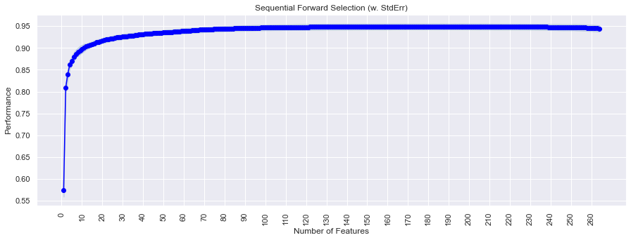

```python
# to plot the performance with addition of each feature
from mlxtend.plotting import plot_sequential_feature_selection as plot_sfs

fig1 = plot_sfs(sfs.get_metric_dict(), kind="std_err", figsize=(15, 5))
plt.title("Sequential Forward Selection (w. StdErr)")
plt.xticks(
    np.arange(0, 264, 10), np.arange(0, 264, 10), rotation=90
)  # to make the tick marks readable
plt.show()
```

- The model performance appears to have become constant somewhere around 120 features and then starts slightly falling around 234 features.
- The improvement in performance from 90 to 120 features is not that high either.
- We will take 90 as the number of features to consider.

```python
reg = LinearRegression()

# # Build step forward feature selection
sfs = SFS(
    reg,
    k_features = 90,
    forward=True,
    floating=False,
    scoring="r2",
    verbose=2,
    cv=5,
    n_jobs=-1,
)

# Perform SFFS
sfs = sfs.fit(x_train, y_train)
```

[output not shown]

[output cut: 283 more lines]

[output not shown]

```python
#To find which features are more important
feat_cols = list(sfs.k_feature_idx_)
print(feat_cols)
```

```
[0, 1, 3, 4, 5, 6, 7, 8, 9, 10, 11, 14, 17, 20, 21, 23, 24, 25, 27, 28, 29, 30, 36, 37, 41, 42, 43, 44, 46, 50, 51, 53, 55, 56, 58, 59, 67, 69, 76, 83, 89, 93, 94, 103, 105, 106, 110, 111, 113, 114, 115, 116, 118, 120, 121, 122, 124, 127, 129, 135, 137, 143, 145, 147, 149, 150, 151, 152, 155, 157, 1…
```

```python
x_train.columns[feat_cols]
```

```
Index(['Year', 'Seats', 'power_numerical_value', 'km_per_unit_fuel',
       'new_price_num', 'kilometers_driven_log', 'Location_Bangalore',
       'Location_Chennai', 'Location_Coimbatore', 'Location_Delhi',
       'Location_Hyderabad', 'Location_Kolkata', 'Fuel_Type_Diesel',
       'Fuel_Type_Petrol', 'Transmission_Manual', 'Owner_Type_Second',
       'Owner_Type_Third', 'Brand_Name_audi', 'Brand_Name_bmw',
       'Brand_Name_chevrolet', 'Brand_Name_datsun', 'Brand_Name_fiat',
       'Brand_Name_jaguar', 'Brand_Name_jeep', 'Brand_Name_maruti',
       'Brand_Name_mercedes-benz', 'Brand_Name_mini', 'Brand_Name_mitsubishi',
       'Brand_Name_porsche', 'Brand_Name_tata', 'Brand_Name_toyota',
       'Brand_Name_volvo', 'Model_Name_3', 'Model_Name_5', 'Model_Name_7',
       'Model_Name_800', 'Model_Name_accent', 'Model_Name_alto',
       'Model_Name_baleno', 'Model_Name_brio', 'Model_Name_cayenne',
       'Model_Name_ciaz', 'Model_Name_city', 'Model_Name_corolla',
       'Model_Name_cr-v', 'Model_Name_creta', 'Model_Name_duster',
       'Model_Name_dzire', 'Model_Name_e-class', 'Model_Name_ecosport',
       'Model_Name_eeco', 'Model_Name_elantra', 'Model_Name_endeavour',
       'Model_Name_eon', 'Model_Name_ertiga', 'Model_Name_esteem',
       'Model_Name_etios', 'Model_Name_fabia', 'Model_Name_figo',
       'Model_Name_gallardo', 'Model_Name_gl-class', 'Model_Name_grand',
       'Model_Name_hexa', 'Model_Name_i20', 'Model_Name_ikon',
       'Model_Name_indica', 'Model_Name_indigo', 'Model_Name_innova',
       'Model_Name_jetta', 'Model_Name_kuv', 'Model_Name_kwid',
       'Model_Name_nano', 'Model_Name_octavia', 'Model_Name_omni',
       'Model_Name_q5', 'Model_Name_q7', 'Model_Name_quanto',
       'Model_Name_rover', 'Model_Name_rs5', 'Model_Name_santro',
       'Model_Name_superb', 'Model_Name_swift', 'Model_Name_terrano',
       'Model_Name_verna', 'Model_Name_vitara', 'Model_Name_x-trail',
       'Model_Name_x1', 'Model_Name_xuv500', 'Model_Name_xylo',
       'Model_Name_yeti'],
      dtype='object')
```

**Now we will fit a sklearn model using these features only.**

```python
x_train2 = x_train[x_train.columns[feat_cols]]
```

```python
x_test2 = x_test[x_train2.columns]
```

```python
# Fitting linear model (regression)
lin_reg_model2 = LinearRegression()
lin_reg_model2.fit(x_train2, y_train)

# let us check the coefficients, intercepts of the linear model

coef_df = pd.DataFrame(
    np.append(lin_reg_model2.coef_, lin_reg_model2.intercept_.flatten()),
    index=x_train2.columns.tolist() + ["Intercept"],
    columns=["Coefficients"],
)
coef_df
```

|  | Coefficients |
| --- | --- |
| Year | 0.111699 |
| Seats | 0.048511 |
| power_numerical_value | 0.004426 |
| km_per_unit_fuel | -0.010504 |
| new_price_num | 0.004012 |
| kilometers_driven_log | -0.072536 |
| Location_Bangalore | 0.202294 |
| Location_Chennai | 0.082304 |
| Location_Coimbatore | 0.159373 |
| Location_Delhi | -0.046894 |
| Location_Hyderabad | 0.174969 |
| Location_Kolkata | -0.182229 |
| Fuel_Type_Diesel | 0.062327 |
| Fuel_Type_Petrol | -0.135832 |
| Transmission_Manual | -0.117404 |
| Owner_Type_Second | -0.052513 |
| Owner_Type_Third | -0.156635 |
| Brand_Name_audi | 0.684103 |
| Brand_Name_bmw | 0.867339 |
| Brand_Name_chevrolet | -0.286435 |
| Brand_Name_datsun | -0.541684 |
| Brand_Name_fiat | -0.259474 |
| Brand_Name_jaguar | 0.746377 |
| Brand_Name_jeep | 0.416208 |
| Brand_Name_maruti | -0.095080 |
| Brand_Name_mercedes-benz | 0.752587 |
| Brand_Name_mini | 1.062659 |
| Brand_Name_mitsubishi | 0.442372 |
| Brand_Name_porsche | 1.018879 |
| Brand_Name_tata | -0.264535 |

[output cut: 61 more lines]

```python
# Model performance on training set
print("Train Performance:")
model_perf(lin_reg_model2, x_train2, y_train)
```

```
Train Performance:
```

|  | RMSE | MAE | R^2 | Adjusted R^2 |
| --- | --- | --- | --- | --- |
| 0 | 3.243689 | 1.379307 | 0.917715 | 0.915919 |

```python
# model performance on testing set
print("Test data Performance:")
model_perf(lin_reg_model2, x_test2, y_test)
```

```
Test data Performance:
```

|  | RMSE | MAE | R^2 | Adjusted R^2 |
| --- | --- | --- | --- | --- |
| 0 | 2.957279 | 1.371427 | 0.926356 | 0.922492 |

**We are getting 92% of the variation in the test data using 90 features**

## Observations

Positive pricing factors:

- Brand
- location
- Maximum power of engine
- Numnber of seats
- Manufacture year

Negative pricing factors:

- Few Brand
- Few Localtion
- Number of kilometers drive
- Distance covered in unit fuel

Variation: We are capturing more than 90% of the variation in test data using our linear regression model

Mean Absolute Error: Our current model can predict the prices of used car withing a mean error of 1.4 lakhs of the test data.

## Analysing predictions by model

```python
# Extracting the rows from original data frame df where indexes are same as the training data
original_df = data1[data1.index.isin(x_train2.index.values)].copy()

# Extracting predicted values and residuals from the final model
fitted_values = lin_reg_model2.predict(x_train2)
residuals = fitted_values - y_train

# Add new columns for predicted values
original_df["Model_Predicted_price_log "] = fitted_values
original_df["Model_Predicted_Price"] = np.exp(fitted_values)
original_df["Residuals"] = residuals
original_df["Absolute_residuals"] = np.exp(residuals)
original_df["Difference in Price(Lakh)"] = np.abs(
    original_df["Price"] - original_df["Model_Predicted_Price"]
)

# Let us look at the top 50 predictions where our model made highest extimation errors (on train data)
original_df.sort_values(by=["Difference in Price(Lakh)"], ascending=False).head(25)
```

|  | Location | Year | Fuel_Type | Transmission | Owner_Type | Seats | Price | engine_numerical_data | power_numerical_value | km_per_unit_fuel | new_price_num | Brand_Name | Model_Name | price_log | kilometers_driven_log | Model_Predicted_price_log | Model_Predicted_Price | Residuals | Absolute_residuals | Difference in Price(Lakh) |
| --- | --- | --- | --- | --- | --- | --- | --- | --- | --- | --- | --- | --- | --- | --- | --- | --- | --- | --- | --- | --- |
| 4079 | Hyderabad | 2017 | Diesel | Automatic | First | 5.0 | 160.00 | 2993.0 | 255.00 | 13.33 | 230.000 | land | rover | 5.075174 | 10.126631 | 0.797889 | 2.220848 | -3.645072e-01 | 0.694539 | 157.779152 |
| 5781 | Delhi | 2011 | Petrol | Automatic | Third | 2.0 | 120.00 | 5204.0 | 560.00 | 6.40 | 11.315 | lamborghini | gallardo | 4.787492 | 8.779557 | 1.066774 | 2.905989 | -7.993606e-15 | 1.000000 | 117.094011 |
| 5065 | Hyderabad | 2016 | Diesel | Manual | First | 5.0 | 5.99 | 1248.0 | 74.00 | 17.80 | 7.880 | maruti | swift | 1.790091 | 11.066638 | 4.787492 | 120.000000 | 2.262195e-01 | 1.253851 | 114.010000 |
| 1363 | Coimbatore | 2018 | Petrol | Automatic | First | 5.0 | 7.55 | 1197.0 | 81.86 | 18.90 | 8.630 | hyundai | grand | 2.021548 | 9.936294 | 4.710667 | 111.126209 | 4.691364e-02 | 1.048032 | 103.576209 |
| 2405 | Coimbatore | 2017 | Petrol | Manual | First | 5.0 | 6.42 | 1196.0 | 86.80 | 18.16 | 7.650 | ford | figo | 1.859418 | 9.986909 | 4.665249 | 106.192009 | -9.098713e-02 | 0.913029 | 99.772009 |
| 5462 | Ahmedabad | 2010 | Diesel | Manual | First | 5.0 | 2.75 | 1248.0 | 73.90 | 19.30 | 7.880 | maruti | swift | 1.011601 | 11.326596 | 4.624565 | 101.958405 | 1.244914e-01 | 1.132572 | 99.208405 |
| 436 | Kochi | 2016 | Petrol | Manual | First | 5.0 | 3.74 | 796.0 | 47.30 | 22.74 | 4.360 | maruti | alto | 1.319086 | 10.441938 | 4.598784 | 99.363395 | -1.863069e-01 | 0.830019 | 95.623395 |
| 1505 | Kochi | 2019 | Diesel | Automatic | First | 5.0 | 97.07 | 2993.0 | 255.00 | 12.65 | 139.000 | land | rover | 4.575432 | 10.166352 | 1.036571 | 2.819533 | -1.771462e-01 | 0.837657 | 94.250467 |
| 1984 | Bangalore | 2017 | Petrol | Automatic | First | 5.0 | 93.00 | 2979.0 | 320.00 | 12.05 | 158.000 | bmw | 7 | 4.532599 | 9.767954 | 0.723011 | 2.060628 | -1.686356e-01 | 0.844817 | 90.939372 |
| 1974 | Coimbatore | 2018 | Petrol | Automatic | First | 5.0 | 93.67 | 2979.0 | 320.00 | 12.05 | 158.000 | bmw | 7 | 4.539778 | 10.242100 | 1.399367 | 4.052634 | -1.414282e-01 | 0.868118 | 89.617366 |
| 4691 | Bangalore | 2014 | Petrol | Automatic | Second | 2.0 | 90.00 | 5461.0 | 421.00 | 12.00 | 49.490 | mercedes-benz | slk-class | 4.499810 | 8.006368 | 1.805786 | 6.084750 | -3.074820e-01 | 0.735296 | 83.915250 |
| 3212 | Hyderabad | 2014 | Diesel | Manual | First | 7.0 | 12.99 | 2494.0 | 102.00 | 12.80 | 24.010 | toyota | innova | 2.564180 | 11.975357 | 4.540535 | 93.740957 | -1.272477e-01 | 0.880516 | 80.750957 |
| 5535 | Ahmedabad | 2015 | Diesel | Automatic | First | 5.0 | 85.00 | 2993.0 | 308.43 | 15.87 | 55.070 | bmw | x6 | 4.442651 | 11.482497 | 1.521416 | 4.578703 | -5.985934e-01 | 0.549584 | 80.421297 |
| 2095 | Coimbatore | 2019 | Petrol | Automatic | First | 2.0 | 83.96 | 2996.0 | 362.07 | 19.00 | 106.000 | mercedes-benz | slc | 4.430340 | 7.834392 | 1.571846 | 4.815530 | 2.349084e-01 | 1.264793 | 79.144470 |
| 4438 | Jaipur | 2019 | Petrol | Manual | First | 5.0 | 3.50 | 796.0 | 47.30 | 24.70 | 4.360 | maruti | alto | 1.252763 | 8.006368 | 4.398350 | 81.316570 | 3.711909e-01 | 1.449460 | 77.816570 |
| 4271 | Delhi | 2010 | Petrol | Automatic | First | 5.0 | 3.55 | 1497.0 | 118.00 | 16.80 | 13.580 | honda | city | 1.266948 | 11.034890 | 4.398286 | 81.311399 | 1.018347e-01 | 1.107200 | 77.761399 |
| 4470 | Kolkata | 2013 | Diesel | Manual | First | 5.0 | 3.30 | 1498.0 | 98.60 | 27.40 | 8.540 | honda | amaze | 1.193922 | 10.747208 | 4.363964 | 78.567955 | 7.663230e-02 | 1.079645 | 75.267955 |
| 2422 | Delhi | 2016 | Diesel | Automatic | First | 4.0 | 79.00 | 2993.0 | 271.23 | 10.50 | 69.675 | jaguar | xj | 4.369448 | 9.392662 | 1.667613 | 5.299502 | -5.281164e-01 | 0.589715 | 73.700498 |
| 5827 | Ahmedabad | 2018 | Diesel | Manual | First | 5.0 | 7.75 | 1396.0 | 88.73 | 22.54 | 10.250 | hyundai | i20 | 2.047693 | 10.308953 | 4.388626 | 80.529709 | 8.642511e-02 | 1.090270 | 72.779709 |
| 655 | Mumbai | 2017 | Petrol | Automatic | First | 5.0 | 75.00 | 1999.0 | 237.40 | 9.43 | 69.675 | jaguar | xj | 4.317488 | 9.259226 | 0.983731 | 2.674417 | -5.960209e-01 | 0.551000 | 72.325583 |
| 3489 | Bangalore | 2013 | Diesel | Automatic | Second | 4.0 | 75.00 | 2967.0 | 300.00 | 17.85 | 136.000 | porsche | panamera | 4.317488 | 9.894850 | 1.060120 | 2.886716 | -6.229404e-02 | 0.939607 | 72.113284 |
| 5424 | Hyderabad | 2013 | Diesel | Manual | First | 5.0 | 2.95 | 1396.0 | 53.50 | 17.20 | 7.630 | tata | indica | 1.081805 | 11.037917 | 4.312067 | 74.594539 | -2.133080e-01 | 0.807907 | 71.644539 |
| 1274 | Hyderabad | 2015 | Petrol | Manual | First | 7.0 | 2.95 | 1196.0 | 73.00 | 15.10 | 4.830 | maruti | eeco | 1.081805 | 11.412143 | 4.279142 | 72.178501 | 1.842898e-01 | 1.202364 | 69.228501 |
| 1365 | Jaipur | 2010 | Diesel | Manual | Second | 5.0 | 1.60 | 1248.0 | 90.00 | 18.80 | 7.630 | tata | manza | 0.470004 | 11.513225 | 4.256272 | 70.546493 | 3.236919e-01 | 1.382221 | 68.946493 |
| 3752 | Kochi | 2015 | Diesel | Automatic | First | 5.0 | 70.66 | 2993.0 | 255.00 | 12.65 | 160.000 | land | rover | 4.257880 | 10.557556 | 0.668308 | 1.950933 | -2.505190e-01 | 0.778397 | 68.709067 |